# Preprocessing Brain- and Body-mass Data from Mammals

Venelin Mitov

2019-03-01

# Data from (Boddy et al. 2012).

At the time of writing this article, there exist two data-files from (Boddy et al. 2012):

1. Supplement to the published article available at https://onlinelibrary.wiley.com/action/downloadSupplement?doi=10.1111%2Fj.1420-9101.2012.02491.x&file=JEB_2491_sm_TableS1.xlsx. This data-file does not contain measurement errors but contains the trait values used in the paper.
2. data-file available at https://datadryad.org/bitstream/handle/10255/dryad.37960/brain_body_database_v2.txt?sequence=1. This data-file contains individual counts and standard deviation estimates for some of the species.

## Reading the data-files and storing them into data.table objects

```r
tmpdir <- "." ##tempdir()

tmppath <- function(file) {
  paste0(tmpdir, "/",file)
}
```

```r
data.BoddyEtAl.1.file <- download.file(
  "https://onlinelibrary.wiley.com/action/downloadSupplement?doi=10.1111%2Fj.1420-9101.2012.02491.x&file=JEB_2491_sm_TableS1.xlsx",
  destfile = tmppath("jeb_2491_sm_tables1.xlsx"))
```

```r
data.BoddyEtAl.1 <- as.data.table(read_excel(tmppath("jeb_2491_sm_tables1.xlsx")))
```

```r
data.BoddyEtAl.2.file <- download.file(
  "https://datadryad.org/bitstream/handle/10255/dryad.37960/brain_body_database_v2.txt?sequence=1",
  destfile = tmppath("brain_body_database_v2.txt"))
```

```r
data.BoddyEtAl.2 <- as.data.table(read.table(tmppath("brain_body_database_v2.txt"), header = TRUE, sep = "\t", quote = ""))
```

## Setting a common key in the two data.tables

Species names consist of two words separated by a space. We concatenate them and replace the space by an underscore to avoid possible bugs due to spaces in later procedures. The same ids will be used as tip.labels in the phylogenetic tree.

```r
# use species names without spaes to annotate the tips
data.BoddyEtAl.1[, SpeciesName2:=sapply(`Species Name`, function(sn) gsub(" ", "_", sn))]

data.BoddyEtAl.1 <- data.BoddyEtAl.1[, list(SpeciesName2,
                                            `Species Name`,
                                            Order,
                                            `Brain Mass (g)`,
                                            `Body Mass (g)`,
                                            Reference,
                                            Notes)]

setkey(data.BoddyEtAl.1, SpeciesName2)
# the one species that was not included in the tree provided by
# Prof. Dr. Joerg Stelling was Microtus_pennsylvanicus
#data.BoddyEtAl.1 <- data.BoddyEtAl.1[SpeciesName2 != "Microtus_pennsylvanicus"]
```

```r
# SpeciesName2 will be the key column in both tables
data.BoddyEtAl.2[, SpeciesName2:=sapply(
  Updated.Species.Name..from.Wilson...Reeder.Mammal.Species.of.the.World.,
  function(sn) gsub(" ", "_", sn))]
```

## Missing species names in data.BoddyEtAl.2

```r
# problem: There is no 1-to-1 mapping between SpeciesName2 in data.BoddyEtAl.2 and
# data.BoddyEtAl.1.
# This returns 51 entries
setdiff(data.BoddyEtAl.1$SpeciesName2, data.BoddyEtAl.2$SpeciesName2)
```

```
##  [1] "Aethomys_namaquensis"      "Agouti_paca"               "Arctocephalus_pusillus"    "Arvicola_terrestris"       "Balaenoptera_borealis"     "Chaerephon_pumila"         "Clethrionomys_gapperi"     "Clethrionomys_glareolus"   "Clethrionomys_rufocanus"   "Clethrionomys_rutilus"     "Cynopterus_…
```

```r
data.BoddyEtAl.2[, SpeciesName3:=sapply(
  Species.Name..from.original.article.,
  function(sn) gsub(" ", "_", sn))]

data.BoddyEtAl.2[SpeciesName3 %in% setdiff(data.BoddyEtAl.1$SpeciesName2,
                                           data.BoddyEtAl.2$SpeciesName2),
                 SpeciesName2:=SpeciesName3]

# This returns 26 entries
setdiff(data.BoddyEtAl.1$SpeciesName2, data.BoddyEtAl.2$SpeciesName2)
```

```
##  [1] "Arctocephalus_pusillus"   "Balaenoptera_borealis"    "Chaerephon_pumila"        "Cynopterus_horsfieldi"    "Dasycercus_byrnei"        "Funisciurus_pyrropus"     "Galagoides_demidoff"      "Gazella_thomsonii"        "Megaptera_novaeangliae"   "Mimon_crenulatum"         "Myomys_daltoni"      …
```

## Finding matching entries between two data.tables manually

```r
missingNamesInData.BoddyEtAl.2 <-
  setdiff(data.BoddyEtAl.1$SpeciesName2, data.BoddyEtAl.2$SpeciesName2)
for(i in seq_along(missingNamesInData.BoddyEtAl.2)) {
  name <- missingNamesInData.BoddyEtAl.2[i]
  cat("i:", i, ", data.BoddyEtAl.1$SpeciesName2:", name, "\n")
  name1 <- strsplit(name, split="_")[[1]][1]
  name2 <- strsplit(name, split="_")[[1]][2]
  # find matches in data.BoddyEtAl.2 according to first letter in name1 and first 3 letters in name2
  cat("data.BoddyEtAl.1:\n")
  print(data.BoddyEtAl.1[SpeciesName2==name])
  cat("data.BoddyEtAl.2:\n")
  Is <- data.BoddyEtAl.2[, .I[sapply(seq_along(SpeciesName2), function(j) {
    sn2 <- SpeciesName2[j]
    updn <- Updated.Species.Name..from.Wilson...Reeder.Mammal.Species.of.the.World.[j]
    orign <- Species.Name..from.original.article.[j]

    (!sn2 %in% data.BoddyEtAl.1$SpeciesName2) &&
      ((length(grep(substr(name1, 1, 1), sn2)) > 0 &&
        length(grep(substr(name2, 1, 3), sn2)) > 0) ||
         (length(grep(substr(name1, 1, 1), updn)) > 0 &&
            length(grep(paste0(" ", substr(name2, 1, 3)), updn)) > 0) ||
         (length(grep(substr(name1, 1, 1), orign)) > 0 &&
            length(grep(paste0(" ", substr(name2, 1, 3)), orign)) > 0))
  })]]
  print(data.BoddyEtAl.2[Is, cbind(I=Is, .SD)])
  cat("\n")
  for(i in seq_len(getOption("width"))) cat("=")
  cat("\n")
}
```

```
## i: 1 , data.BoddyEtAl.1$SpeciesName2: Arctocephalus_pusillus
## data.BoddyEtAl.1:
##              SpeciesName2           Species Name     Order Brain Mass (g) Body Mass (g)           Reference Notes
## 1: Arctocephalus_pusillus Arctocephalus pusillus Carnivora          369.4        178750 Bininda-Emonds 2000  <NA>
## data.BoddyEtAl.2:
##     I Updated.Species.Name..from.Wilson...Reeder.Mammal.Species.of.the.World. Species.Name..from.original.article.     Order Brain.Volume Brain.Volume.Standard.Deviation Brain.Mass..g. Brain.Mass.Standard.Deviation Body.Mass..g. Body.Mass.Standard.Deviation Sex No..Individuals Age.Class          …
## 1: 87                                                 Arctocephalus pusillus      Arctocephalus pusillus doriferus Carnivora           NA                              NA          352.5                            NA         78000                           NA   F               1     Adult Bininda-E…
## 2: 88                                                 Arctocephalus pusillus       Arctocephalus pusillus pusillus Carnivora           NA                              NA          322.5                            NA         78000                           NA   F               1     Adult Bininda-E…
## 3: 89                                                 Arctocephalus pusillus      Arctocephalus pusillus doriferus Carnivora           NA                              NA          425.0                            NA        279500                           NA   M               1     Adult Bininda-E…
## 4: 90                                                 Arctocephalus pusillus       Arctocephalus pusillus pusillus Carnivora           NA                              NA          377.5                            NA        279500                           NA   M               1     Adult Bininda-E…
##
## =========================================================================================================================================================================================================================================================================================================…
## i: 2 , data.BoddyEtAl.1$SpeciesName2: Balaenoptera_borealis
## data.BoddyEtAl.1:
##             SpeciesName2          Species Name           Order Brain Mass (g) Body Mass (g)                                  Reference Notes
## 1: Balaenoptera_borealis Balaenoptera borealis Cetartiodactyla           4900      36666667 Jacobs & Jensen 1964; Silva & Downing 1995  <NA>
## data.BoddyEtAl.2:
## Empty data.table (0 rows) of 17 cols: I,Updated.Species.Name..from.Wilson...Reeder.Mammal.Species.of.the.World.,Species.Name..from.original.article.,Order,Brain.Volume,Brain.Volume.Standard.Deviation...
##
## =========================================================================================================================================================================================================================================================================================================…
## i: 3 , data.BoddyEtAl.1$SpeciesName2: Chaerephon_pumila
## data.BoddyEtAl.1:
##         SpeciesName2      Species Name      Order Brain Mass (g) Body Mass (g)             Reference Notes
## 1: Chaerephon_pumila Chaerephon pumila Chiroptera           0.29          13.3 Pirlot & Stephan 1970  <NA>
## data.BoddyEtAl.2:
##      I Updated.Species.Name..from.Wilson...Reeder.Mammal.Species.of.the.World. Species.Name..from.original.article.      Order Brain.Volume Brain.Volume.Standard.Deviation Brain.Mass..g. Brain.Mass.Standard.Deviation Body.Mass..g. Body.Mass.Standard.Deviation  Sex No..Individuals Age.Class       …
## 1: 347                                                      Chaerephon pumilus                  Chaerophon limbatus Chiroptera           NA                              NA           0.29                            NA          13.3                           NA <NA>               4     Adult Pirlot…
##
## =========================================================================================================================================================================================================================================================================================================…
## i: 4 , data.BoddyEtAl.1$SpeciesName2: Cynopterus_horsfieldi
## data.BoddyEtAl.1:
##             SpeciesName2          Species Name      Order Brain Mass (g) Body Mass (g)             Reference Notes
## 1: Cynopterus_horsfieldi Cynopterus horsfieldi Chiroptera           1.23            53 Pirlot & Stephan 1970  <NA>
## data.BoddyEtAl.2:
##      I Updated.Species.Name..from.Wilson...Reeder.Mammal.Species.of.the.World. Species.Name..from.original.article.      Order Brain.Volume Brain.Volume.Standard.Deviation Brain.Mass..g. Brain.Mass.Standard.Deviation Body.Mass..g. Body.Mass.Standard.Deviation  Sex No..Individuals Age.Class       …
## 1: 432                                                  Cynopterus horsfieldii                Cynopterus horsfeldii Chiroptera           NA                              NA           1.23                            NA            53                           NA <NA>              15     Adult Pirlot…
##
## =========================================================================================================================================================================================================================================================================================================…
## i: 5 , data.BoddyEtAl.1$SpeciesName2: Dasycercus_byrnei
## data.BoddyEtAl.1:
```

[output cut: 178 more lines]

```
##       SpeciesName2    Species Name    Order Brain Mass (g) Body Mass (g) Reference                                                                  Notes
## 1: Tatera_brantsii Tatera brantsii Rodentia           1.56          91.7 Mace 1981 Corrected body mass for Mace 1981 dataset, see Isler & van Schaik 2006
## data.BoddyEtAl.2:
##      I Updated.Species.Name..from.Wilson...Reeder.Mammal.Species.of.the.World. Species.Name..from.original.article.    Order Brain.Volume Brain.Volume.Standard.Deviation Brain.Mass..g. Brain.Mass.Standard.Deviation Body.Mass..g. Body.Mass.Standard.Deviation Sex No..Individuals Age.Class    Source…
## 1: 666                                                   Gerbilliscus brantsii                       Tatera brantsi Rodentia           NA                              NA           1.56                            NA          91.7                           NA M&F              NA     Adult Mace 1981…
##
## =========================================================================================================================================================================================================================================================================================================…
## i: 26 , data.BoddyEtAl.1$SpeciesName2: Zaglossus_bruijni
## data.BoddyEtAl.1:
##         SpeciesName2      Species Name       Order Brain Mass (g) Body Mass (g)    Reference Notes
## 1: Zaglossus_bruijni Zaglossus bruijni Monotremata          37.35          7500 Macrini 2006  <NA>
## data.BoddyEtAl.2:
## Empty data.table (0 rows) of 17 cols: I,Updated.Species.Name..from.Wilson...Reeder.Mammal.Species.of.the.World.,Species.Name..from.original.article.,Order,Brain.Volume,Brain.Volume.Standard.Deviation...
##
## =========================================================================================================================================================================================================================================================================================================…
```

```r
manual.Match <- list()

manual.Match[["Arctocephalus_pusillus"]] <- 87:90
manual.Match[["Chaerephon_pumila"]] <- 347
manual.Match[["Cynopterus_horsfieldi"]] <- 432
manual.Match[["Dasycercus_byrnei"]] <- 457
manual.Match[["Funisciurus_pyrropus"]] <- 644
manual.Match[["Galagoides_demidoff"]] <- 645
manual.Match[["Gazella_thomsonii"]] <- 616:617
manual.Match[["Mimon_crenulatum"]] <- 1148
manual.Match[["Myotis_bechsteini"]] <- 1197
manual.Match[["Myotis_daubentoni"]] <- 1200
manual.Match[["Phacochoerus_aethiopicus"]] <- 1469
manual.Match[["Pogonomelomys_sevia"]] <- 1
manual.Match[["Procolobus_badius"]] <- 1508
manual.Match[["Rousettus_egyptiacus"]] <- 1663
manual.Match[["Spermophilus_franklinii"]] <- 1777
manual.Match[["Tamiops_macclellandi"]] <- 1866
manual.Match[["Tatera_brantsii"]] <- 666
manual.Match[["Myomys_daltoni"]] <- 1556
manual.Match[["Sminthopsis_laniger"]] <- 48
manual.Match[["Stenomys_niobe"]] <- 1632
manual.Match[["Stenomys_verecundus"]] <- 1645

for(name in names(manual.Match)) {
  data.BoddyEtAl.2[manual.Match[[name]], SpeciesName2:=name]
  data.BoddyEtAl.1[
    list(name),
    Notes:=paste0(Notes[!is.na(Notes)],
                  "; Mitov: Manual match with lines ",
                  toString(manual.Match[[name]]),
                  " in data.BoddyEtAl.2. ")]
}
```

## Entries data.BoddyEtAl.1 left without a matching row in data.BoddyEtAl.2:

```r
data.BoddyEtAl.1[
  list(setdiff(data.BoddyEtAl.1$SpeciesName2, data.BoddyEtAl.2$SpeciesName2))]
```

```
##                SpeciesName2             Species Name           Order Brain Mass (g) Body Mass (g)                                  Reference Notes
## 1:    Balaenoptera_borealis    Balaenoptera borealis Cetartiodactyla        4900.00      36666667 Jacobs & Jensen 1964; Silva & Downing 1995  <NA>
## 2:   Megaptera_novaeangliae   Megaptera novaeangliae Cetartiodactyla        6100.00      30050000 Jacobs & Jensen 1964; Silva & Downing 1995  <NA>
## 3: Ornithorhynchus_anatinus Ornithorhynchus anatinus     Monotremata          10.08          1389                               Macrini 2006  <NA>
## 4:   Tachyglossus_aculeatus   Tachyglossus aculeatus     Monotremata          20.73          4250                               Macrini 2006  <NA>
## 5:        Zaglossus_bruijni        Zaglossus bruijni     Monotremata          37.35          7500                               Macrini 2006  <NA>
```

## Filtering-out non-adult measurements in data.BoddyEtAl.2 with a note for emaciation

According to Boddy et. Al. 2012, only measurements from adult and non-emaciated individuals were used. Hence, the measurements for a given species have been averaged over adult males and females. For Rodentias reported in Mace et Al. 1981, a correction to the Brain-mass was done by subtracting 0.59 grams following the prescription from Isler & van Schaik 2006 (Boddy et al. 2012). This correction was already integrated in both, data.BoddyEtAl.1 and data.BoddyEtAl.2.

We begin by filtering out the non-adult measurements from data.BodyEtAl.2 which have a note for emaciation:

```r
data.BoddyEtAl.2 <- data.BoddyEtAl.2[setdiff(seq_len(.N), grep("emaciated", Notes))][
  Age.Class=="Adult",
  list(
    SpeciesName2,
    Order = Order,
    Brain.Mass..g., Brain.Mass.SD = Brain.Mass.Standard.Deviation,
    Body.Mass..g., Body.Mass.SD = Body.Mass.Standard.Deviation,
    Sex, No..Individuals, Source, Notes)]

setkey(data.BoddyEtAl.2, SpeciesName2)
```

We notice that apparently some measurements without a note for emaciation were still excluded from data.BoddyEtAl.2. We did not find an instruction of how this was done in (Boddy et al. 2012). Later on, we will identify such measurements based on maximum match between the two data.tables.

## Add 7 missing species to data.BoddyEtAl.2

After filtering out the measurements from non-adult individuals there are 7 species and data.BoddyEtAl.1 without any measurement left in data.BoddyEtAl.2:

```r
data.BoddyEtAl.1[
  list(setdiff(data.BoddyEtAl.1$SpeciesName2, data.BoddyEtAl.2$SpeciesName2))]
```

```
##                SpeciesName2             Species Name           Order Brain Mass (g) Body Mass (g)                                                Reference Notes
## 1:    Balaenoptera_borealis    Balaenoptera borealis Cetartiodactyla        4900.00      36666667               Jacobs & Jensen 1964; Silva & Downing 1995  <NA>
## 2:    Balaenoptera_physalus    Balaenoptera physalus Cetartiodactyla        5100.00      62500000               Jacobs & Jensen 1964; Silva & Downing 1995  <NA>
## 3:    Hylobates_syndactylus    Hylobates syndactylus        Primates         134.80         12172 Hrdlicka 1925; Sherwood/this study; Silva & Downing 1995  <NA>
## 4:   Megaptera_novaeangliae   Megaptera novaeangliae Cetartiodactyla        6100.00      30050000               Jacobs & Jensen 1964; Silva & Downing 1995  <NA>
## 5: Ornithorhynchus_anatinus Ornithorhynchus anatinus     Monotremata          10.08          1389                                             Macrini 2006  <NA>
## 6:   Tachyglossus_aculeatus   Tachyglossus aculeatus     Monotremata          20.73          4250                                             Macrini 2006  <NA>
## 7:        Zaglossus_bruijni        Zaglossus bruijni     Monotremata          37.35          7500                                             Macrini 2006  <NA>
```

We add (copy) these entries from data.BoddyEtAl.1 to the corresponding columns in data.BoddyEtAl.2:

```r
data.BoddyEtAl.2 <- rbindlist(
  list(data.BoddyEtAl.2,
       data.BoddyEtAl.1[list(setdiff(data.BoddyEtAl.1$SpeciesName2,
                                     data.BoddyEtAl.2$SpeciesName2)),
                        list(SpeciesName2,
                             Order = Order,
                             Brain.Mass..g. = `Brain Mass (g)`,
                             Brain.Mass.SD = as.double(NA),
                             Body.Mass..g. = `Body Mass (g)`,
                             Body.Mass.SD = as.double(NA),
                             Sex = as.character(NA),
                             No..Individuals = as.integer(NA),
                             Source = Reference,
                             Notes = paste(Notes, "; Mitov: measurements copied from data.BoddyEtAl.1 (https://onlinelibrary.wiley.com/action/downloadSupplement?doi=10.1111%2Fj.1420-9101.2012.02491.x&file=JEB_2491_sm_TableS1.xlsx)."))])
)

setkey(data.BoddyEtAl.2, SpeciesName2)
```

## Create an i column in data.BoddyEtAl.2

```r
data.BoddyEtAl.2[, i:=.I]
```

## Correcting the Order in data.BoddyEtAl.2 according to the order for the corresponding species in data.BoddyEtAl.1

```r
# to see which measurements have differring order:
data.BoddyEtAl.2[
  data.BoddyEtAl.1[, list(SpeciesName2, Order)]][Order!=i.Order]
```

```
##              SpeciesName2            Order Brain.Mass..g. Brain.Mass.SD Body.Mass..g. Body.Mass.SD  Sex No..Individuals                   Source                                                                          Notes    i         i.Order
##  1:  Atelerix_albiventris   Erinaceomorpha           2.24            NA         280.0           NA  M&F              NA                Mace 1981                                                                                  61    Eulipotyphla
##  2:      Atelerix_algirus   Erinaceomorpha           3.20            NA         790.0           NA <NA>               3             Stephan 1981                                             Age class estimated from body mass   62    Eulipotyphla
##  3:   Erinaceus_europaeus   Erinaceomorpha           2.26            NA         372.0           NA <NA>               1         Glendenning 1998                                                                                 318    Eulipotyphla
##  4:   Erinaceus_europaeus   Erinaceomorpha           3.77            NA         697.0           NA  M&F              NA                Mace 1981                                                                                 319    Eulipotyphla
##  5:   Erinaceus_europaeus   Erinaceomorpha           3.35            NA         860.0           NA <NA>               5             Stephan 1981                                             Age class estimated from body mass  320    Eulipotyphla
##  6:   Erinaceus_europaeus   Erinaceomorpha           6.50            NA         718.0           NA <NA>               1             Warncke 1908                                                                                 321    Eulipotyphla
##  7:   Erinaceus_europaeus   Erinaceomorpha           3.60            NA         669.0           NA <NA>               1             Warncke 1908                                                                                 322    Eulipotyphla
##  8:   Erinaceus_europaeus   Erinaceomorpha           3.50            NA         515.0           NA <NA>               1             Warncke 1908                                                                                 323    Eulipotyphla
##  9:   Erinaceus_europaeus   Erinaceomorpha           3.00            NA         497.8           NA <NA>               1             Warncke 1908                                                                                 324    Eulipotyphla
## 10:   Erinaceus_europaeus   Erinaceomorpha           3.30            NA         925.0           NA <NA>               1             Warncke 1908                                                                                 325    Eulipotyphla
## 11:   Erinaceus_europaeus   Erinaceomorpha           3.50            NA         920.0           NA <NA>               1             Warncke 1908                                                                                 326    Eulipotyphla
## 12:   Erinaceus_europaeus   Erinaceomorpha           3.30            NA         985.0           NA <NA>               1             Warncke 1908                                                                                 327    Eulipotyphla
## 13:   Erinaceus_europaeus   Erinaceomorpha           3.50            NA         448.0           NA <NA>               1             Warncke 1908                                                                                 328    Eulipotyphla
## 14:   Erinaceus_europaeus   Erinaceomorpha           3.00            NA         690.0           NA <NA>               1             Warncke 1908                                                                                 329    Eulipotyphla
## 15:   Hemiechinus_auritus   Erinaceomorpha           1.90            NA         250.0           NA <NA>               3             Stephan 1981                                             Age class estimated from body mass  402    Eulipotyphla
## 16: Tragelaphus_eurycerus Cetartiodactyla          389.00            NA      253000.0           NA    F              NA Sherwood data/this study Estimated age of species: 9.5 y; Body mass estimated from Silva & Downing 1995 1111 Cetartiodactyla
```

```r
# delete the Order column from data.BodyEtAl.2
data.BoddyEtAl.2[, Order:=NULL]

data.BoddyEtAl.2 <- data.BoddyEtAl.2[
  data.BoddyEtAl.1[, list(SpeciesName2, Order)]]
```

## Filling-in the missing No..individuals in data.BoddyEtAl.2

To calculate the standard error for each measurement we need the standard deviation and the number of individuals. For many of the measurements in data.BoddyEtAl.2 the number of individuals (column `No..Individuals`) was `NA`. It is clear that if the value of the colum `Sex` is “M&F” there have to be at least two individuals taking part in the measurement. Hence, we stratify the measurements in categories according to the `Sex` column. Then, in each category we set the unknown `No..Individuals` value to the median of the known `No..Individuals` values.

```r
data.BoddyEtAl.2[is.na(No..Individuals) & is.na(Sex)]
```

```
##                  SpeciesName2 Brain.Mass..g. Brain.Mass.SD Body.Mass..g. Body.Mass.SD  Sex No..Individuals                                                   Source                                                                                                                                      …
##  1:         Apodemus_agrarius           0.20            NA     3.330e+01           NA <NA>              NA                          Count 1947 (Brummelkamp 1939b)                                                                                                                                       …
##  2:       Apodemus_sylvaticus           0.59            NA     2.160e+01           NA <NA>              NA                          Count 1947 (Brummelkamp 1939b)                                                                                                                                       …
##  3:     Balaenoptera_borealis        4900.00            NA     3.667e+07           NA <NA>              NA               Jacobs & Jensen 1964; Silva & Downing 1995 NA ; Mitov: measurements copied from data.BoddyEtAl.1 (https://onlinelibrary.wiley.com/action/downloadSupplement?doi=10.1111%2Fj.1420…
##  4:     Balaenoptera_physalus        5100.00            NA     6.250e+07           NA <NA>              NA               Jacobs & Jensen 1964; Silva & Downing 1995 NA ; Mitov: measurements copied from data.BoddyEtAl.1 (https://onlinelibrary.wiley.com/action/downloadSupplement?doi=10.1111%2Fj.1420…
##  5:       Dasyprocta_leporina          20.00            NA     2.684e+03           NA <NA>              NA                          Count 1947 (Brummelkamp 1939b)                                                                                                                                       …
##  6: Hydrochaeris_hydrochaeris          75.00            NA     2.850e+04           NA <NA>              NA                          Count 1947 (Brummelkamp 1939b)                                                                                                                                       …
##  7:     Hylobates_syndactylus         134.80            NA     1.217e+04           NA <NA>              NA Hrdlicka 1925; Sherwood/this study; Silva & Downing 1995 NA ; Mitov: measurements copied from data.BoddyEtAl.1 (https://onlinelibrary.wiley.com/action/downloadSupplement?doi=10.1111%2Fj.1420…
##  8:           Jaculus_jaculus           1.85            NA     7.300e+01           NA <NA>              NA                          Count 1947 (Brummelkamp 1939b)                                                                                                                                       …
##  9:        Lagostomus_maximus           8.80            NA     3.854e+03           NA <NA>              NA                          Count 1947 (Brummelkamp 1939b)                                                                                                                                       …
## 10:   Leptonychotes_weddellii         520.00            NA     4.000e+05           NA <NA>              NA                                               Robin 1973                                                                                                                                      …
## 11:             Lepus_timidus          16.70            NA     3.833e+03           NA <NA>              NA                          Count 1947 (Brummelkamp 1939b)                                                                                                                                       …
## 12:    Megaptera_novaeangliae        6100.00            NA     3.005e+07           NA <NA>              NA               Jacobs & Jensen 1964; Silva & Downing 1995 NA ; Mitov: measurements copied from data.BoddyEtAl.1 (https://onlinelibrary.wiley.com/action/downloadSupplement?doi=10.1111%2Fj.1420…
## 13:         Microtus_agrestis           0.90            NA     4.250e+01           NA <NA>              NA                          Count 1947 (Brummelkamp 1939b)                                                                                                                                       …
## 14:  Ornithorhynchus_anatinus          10.08            NA     1.389e+03           NA <NA>              NA                                             Macrini 2006 NA ; Mitov: measurements copied from data.BoddyEtAl.1 (https://onlinelibrary.wiley.com/action/downloadSupplement?doi=10.1111%2Fj.1420…
## 15:     Petaurista_petaurista          11.80            NA     1.600e+03           NA <NA>              NA                          Count 1947 (Brummelkamp 1939b)                                                                                                                                       …
```

[output cut: 8 more lines]

```r
data.BoddyEtAl.2[is.na(No..Individuals) & Sex == "F"]
```

```
##             SpeciesName2 Brain.Mass..g. Brain.Mass.SD Body.Mass..g. Body.Mass.SD Sex No..Individuals                   Source                                                                              Notes    i           Order
## 1:           Agouti_paca           28.9            NA            NA           NA   F              NA Sherwood data/this study                Estimated age of species: >2 y; Body mass estimated from Nowak 1991    8        Rodentia
## 2:  Choloepus_didactylus           28.2            NA          5070           NA   F              NA Sherwood data/this study       Estimated age of species:>8 y; Body mass estimated from Silva & Downing 1995  197       Xenarthra
## 3:   Damaliscus_pygargus          254.6            NA         62500           NA   F              NA Sherwood data/this study               Estimated age of species: 4.1 y; Body mass estimated from Myers 2006  231 Cetartiodactyla
## 4:        Macropus_parma           17.4            NA          3760           NA   F              NA Sherwood data/this study "Estimated age of species: 2 y, 2m; Body mass estimated from Silva & Downing 1995"  569   Diprotodontia
## 5:  Macropus_rufogriseus           39.0            NA         12425           NA   F              NA Sherwood data/this study      Estimated age of species: 13 y; Body mass estimated from Silva & Downing 1995  573   Diprotodontia
## 6:   Rhynchocyon_petersi            5.4            NA           370           NA   F              NA Sherwood data/this study                  Estimated age of species: 5y; Body mass estimated from Nowak 1991  950   Macroscelidea
## 7: Tamandua_tetradactyla           30.0            NA          5030           NA   F              NA Sherwood data/this study    Estimated age of species: > 6 yr; Body mass estimated from Silva & Downing 1995 1077       Xenarthra
## 8: Tragelaphus_eurycerus          389.0            NA        253000           NA   F              NA Sherwood data/this study     Estimated age of species: 9.5 y; Body mass estimated from Silva & Downing 1995 1111 Cetartiodactyla
## 9:          Ursus_arctos          385.0            NA        100500           NA   F              NA Sherwood data/this study      Estimated age of species: 39 y; Body mass estimated from Silva & Downing 1995 1162       Carnivora
```

```r
data.BoddyEtAl.2[is.na(No..Individuals) & Sex == "M"]
```

```
##        SpeciesName2 Brain.Mass..g. Brain.Mass.SD Body.Mass..g. Body.Mass.SD Sex No..Individuals                   Source                                                                             Notes    i         Order
## 1:  Panthera_tigris          282.2            NA        216000           NA   M              NA Sherwood data/this study    Estimated age of species: 18.5y; Body mass estimated from Silva & Downing 1995  760     Carnivora
## 2: Wallabia_bicolor           32.7            NA         16400           NA   M              NA Sherwood data/this study "Estimated age of species: 2y, 1m: Body mass estimated from Silva & Downing 1995" 1176 Diprotodontia
```

```r
data.BoddyEtAl.2[is.na(No..Individuals) & Sex == "M&F"]
```

```
##               SpeciesName2 Brain.Mass..g. Brain.Mass.SD Body.Mass..g. Body.Mass.SD Sex No..Individuals    Source                                                                                                                    Notes    i    Order
##   1:        Acomys_wilsoni           0.58            NA          18.5           NA M&F              NA Mace 1981 "Body mass averaged from Silva & Downing 1995; Brain mass corrected, subtracted 0.59g from brain weight, see Isler 2006"    2 Rodentia
##   2:   Aeromys_tephromelas          10.34            NA        1189.0           NA M&F              NA Mace 1981                                               "Brain mass corrected, subtracted 0.59g from brain weight, see Isler 2006"    4 Rodentia
##   3: Aethomys_chrysophilus           1.25            NA         117.0           NA M&F              NA Mace 1981                                               "Brain mass corrected, subtracted 0.59g from brain weight, see Isler 2006"    5 Rodentia
##   4:       Aethomys_hindei           1.42            NA         146.3           NA M&F              NA Mace 1981                                               "Brain mass corrected, subtracted 0.59g from brain weight, see Isler 2006"    6 Rodentia
##   5:  Aethomys_namaquensis           0.89            NA          79.4           NA M&F              NA Mace 1981                                               "Brain mass corrected, subtracted 0.59g from brain weight, see Isler 2006"    7 Rodentia
##  ---
## 245:      Xerus_erythropus           6.68            NA         722.5           NA M&F              NA Mace 1981                                               "Brain mass corrected, subtracted 0.59g from brain weight, see Isler 2006" 1177 Rodentia
## 246:         Xerus_inauris           7.65            NA         400.0           NA M&F              NA Mace 1981                                               "Brain mass corrected, subtracted 0.59g from brain weight, see Isler 2006" 1178 Rodentia
## 247:         Xerus_rutilus           5.09            NA         317.5           NA M&F              NA Mace 1981                                               "Brain mass corrected, subtracted 0.59g from brain weight, see Isler 2006" 1179 Rodentia
## 248:       Zapus_hudsonius           0.43            NA          17.9           NA M&F              NA Mace 1981                                               "Brain mass corrected, subtracted 0.59g from brain weight, see Isler 2006" 1184 Rodentia
## 249:        Zapus_princeps           0.50            NA          24.5           NA M&F              NA Mace 1981                                               "Brain mass corrected, subtracted 0.59g from brain weight, see Isler 2006" 1185 Rodentia
```

```r
data.BoddyEtAl.2[is.na(No..Individuals)]
```

```
##               SpeciesName2 Brain.Mass..g. Brain.Mass.SD Body.Mass..g. Body.Mass.SD  Sex No..Individuals       Source                                                                                                                                                                                   No…
##   1:        Acomys_wilsoni           0.58            NA          18.5           NA  M&F              NA    Mace 1981                                                                "Body mass averaged from Silva & Downing 1995; Brain mass corrected, subtracted 0.59g from brain weight, see Isler 20…
##   2:   Aeromys_tephromelas          10.34            NA        1189.0           NA  M&F              NA    Mace 1981                                                                                                              "Brain mass corrected, subtracted 0.59g from brain weight, see Isler 20…
##   3: Aethomys_chrysophilus           1.25            NA         117.0           NA  M&F              NA    Mace 1981                                                                                                              "Brain mass corrected, subtracted 0.59g from brain weight, see Isler 20…
##   4:       Aethomys_hindei           1.42            NA         146.3           NA  M&F              NA    Mace 1981                                                                                                              "Brain mass corrected, subtracted 0.59g from brain weight, see Isler 20…
##   5:  Aethomys_namaquensis           0.89            NA          79.4           NA  M&F              NA    Mace 1981                                                                                                              "Brain mass corrected, subtracted 0.59g from brain weight, see Isler 20…
##  ---
## 278:         Xerus_inauris           7.65            NA         400.0           NA  M&F              NA    Mace 1981                                                                                                              "Brain mass corrected, subtracted 0.59g from brain weight, see Isler 20…
## 279:         Xerus_rutilus           5.09            NA         317.5           NA  M&F              NA    Mace 1981                                                                                                              "Brain mass corrected, subtracted 0.59g from brain weight, see Isler 20…
## 280:     Zaglossus_bruijni          37.35            NA        7500.0           NA <NA>              NA Macrini 2006 NA ; Mitov: measurements copied from data.BoddyEtAl.1 (https://onlinelibrary.wiley.com/action/downloadSupplement?doi=10.1111%2Fj.1420-9101.2012.02491.x&file=JEB_2491_sm_TableS1.xls…
## 281:       Zapus_hudsonius           0.43            NA          17.9           NA  M&F              NA    Mace 1981                                                                                                              "Brain mass corrected, subtracted 0.59g from brain weight, see Isler 20…
## 282:        Zapus_princeps           0.50            NA          24.5           NA  M&F              NA    Mace 1981                                                                                                              "Brain mass corrected, subtracted 0.59g from brain weight, see Isler 20…
```

Medians of the known `No..Individuals` values:

```r
data.BoddyEtAl.2[!is.na(No..Individuals) & is.na(Sex), median(No..Individuals)]
```

```
## [1] 1
```

```r
data.BoddyEtAl.2[!is.na(No..Individuals) & Sex == "F", median(No..Individuals)]
```

```
## [1] 1
```

```r
data.BoddyEtAl.2[!is.na(No..Individuals) & Sex == "M", median(No..Individuals)]
```

```
## [1] 1
```

```r
data.BoddyEtAl.2[!is.na(No..Individuals) & Sex == "M&F", median(No..Individuals)]
```

```
## [1] 10
```

```r
data.BoddyEtAl.2[!is.na(No..Individuals), median(No..Individuals)]
```

```
## [1] 1
```

Assign the medians to the corresponding unknown values:

```r
data.BoddyEtAl.2[is.na(No..Individuals), Notes:=paste(Notes, "; Mitov: Inferred No..Individuals - median from the present No..Individuals for the corresponding value of Sex.")]
data.BoddyEtAl.2[is.na(No..Individuals) & is.na(Sex), No..Individuals:=1L]
data.BoddyEtAl.2[is.na(No..Individuals) & Sex == "F", No..Individuals:=1L]
data.BoddyEtAl.2[is.na(No..Individuals) & Sex == "M", No..Individuals:=1L]
data.BoddyEtAl.2[is.na(No..Individuals) & Sex == "M&F", No..Individuals:=10L]
data.BoddyEtAl.2[is.na(No..Individuals), No..Individuals:=1L]
```

## Filling-in missing Brain- and Body-mass measurements in data.BoddyEtAl.2

For 4 of the measurements in data.BoddyEtAl.2, either the Brain- or the Body-mass is missing. For one measurement (Agouti paca), there was no other measurement of the same species in data.BoddyEtAl.2, so we take the corresponding value from data.BoddyEtAl.1. For the other 3 missing measurements, there are other measurements for the same species in data.BoddyEtAl.2, so we assign the missing value to the mean of the other measurements for the same species.

```r
data.BoddyEtAl.2[(is.na(Brain.Mass..g.) | is.na(Body.Mass..g.))]
```

```
##              SpeciesName2 Brain.Mass..g. Brain.Mass.SD Body.Mass..g. Body.Mass.SD  Sex No..Individuals                   Source                                                                                                                                                                          …
## 1:            Agouti_paca           28.9            NA            NA           NA    F               1 Sherwood data/this study Estimated age of species: >2 y; Body mass estimated from Nowak 1991 ; Mitov: Inferred No..Individuals - median from the present No..Individuals for the corresponding val…
## 2: Leontopithecus_rosalia           14.0            NA            NA           NA <NA>               1             Warncke 1908                                                                                                                                                                          …
## 3: Odocoileus_virginianus             NA            NA         13930           NA    F               1     Crile & Quiring 1940                                                                                                                                                                          …
## 4:    Sciurus_granatensis             NA            NA           287           NA <NA>               1     Crile & Quiring 1940                                                                                                                                                                          …
```

```r
missing.Brain.Mass..g. <- data.BoddyEtAl.2[is.na(Brain.Mass..g.), SpeciesName2]
missing.Body.Mass..g. <- data.BoddyEtAl.2[is.na(Body.Mass..g.), SpeciesName2]

data.BoddyEtAl.2[list(missing.Brain.Mass..g.)]
```

```
##              SpeciesName2 Brain.Mass..g. Brain.Mass.SD Body.Mass..g. Body.Mass.SD  Sex No..Individuals               Source                                                                                                                                                                              …
## 1: Odocoileus_virginianus         210.00            NA         65090           NA    F               2 Crile & Quiring 1940                                                                                                                                                         Age class estimated f…
## 2: Odocoileus_virginianus             NA            NA         13930           NA    F               1 Crile & Quiring 1940                                                                                                                                                                              …
## 3: Odocoileus_virginianus         160.00            NA         40000           NA <NA>               1     Glendenning 1998                                                                                                                                                                              …
## 4:    Sciurus_granatensis             NA            NA           287           NA <NA>               1 Crile & Quiring 1940                                                                                                                                                                              …
## 5:    Sciurus_granatensis           5.91            NA           400           NA  M&F              10            Mace 1981 "Brain mass corrected, subtracted 0.59g from brain weight, see Isler 2006" ; Mitov: Inferred No..Individuals - median from the present No..Individuals for the corresponding …
```

```r
data.BoddyEtAl.2[list(missing.Body.Mass..g.)]
```

```
##              SpeciesName2 Brain.Mass..g. Brain.Mass.SD Body.Mass..g. Body.Mass.SD  Sex No..Individuals                   Source                                                                                                                                                                          …
## 1:            Agouti_paca           28.9            NA            NA           NA    F               1 Sherwood data/this study Estimated age of species: >2 y; Body mass estimated from Nowak 1991 ; Mitov: Inferred No..Individuals - median from the present No..Individuals for the corresponding val…
## 2: Leontopithecus_rosalia           11.7            NA         502.5           NA    M               1 Sherwood data/this study                                                                                                        Estimated age of species: 6.5; Body mass estimated from Silva & Do…
## 3: Leontopithecus_rosalia           12.7            NA         570.0           NA    F               1 Sherwood data/this study                                                                                                        Estimated age of species: 6.5; Body mass estimated from Silva & Do…
## 4: Leontopithecus_rosalia           15.1            NA         570.0           NA    F               1 Sherwood data/this study                                                                                                        Estimated age of species: 6.5; Body mass estimated from Silva & Do…
## 5: Leontopithecus_rosalia           14.0            NA            NA           NA <NA>               1             Warncke 1908                                                                                                                                                                          …
## 6: Leontopithecus_rosalia           12.7            NA         407.0           NA <NA>               1             Warncke 1908                                                                                                                                                                          …
```

```r
for(name in missing.Brain.Mass..g.) {
  meanOthers <- data.BoddyEtAl.2[SpeciesName2 == name & !is.na(Brain.Mass..g.),
                                 sum(Brain.Mass..g.*No..Individuals)/sum(No..Individuals)]
  if(!is.na(meanOthers)) {
    data.BoddyEtAl.2[SpeciesName2 == name & is.na(Brain.Mass..g.),
                     Notes:=paste(Notes, "; Mitov: Brain mass assigned from the mean of the Brain values from the other measurements for the species", sep = ";")]
    data.BoddyEtAl.2[SpeciesName2 == name & is.na(Brain.Mass..g.),
                     Brain.Mass..g.:=meanOthers]
  } else {
    value.data.BoddyEtAl.1 <- data.BoddyEtAl.1[list(name), `Brain Mass (g)`]
    data.BoddyEtAl.2[SpeciesName2 == name & is.na(Brain.Mass..g.),
                     Notes:=paste(Notes, "; Mitov: Brain mass assigned from the value for the same species from data.BoddyEtAl.1 (https://onlinelibrary.wiley.com/action/downloadSupplement?doi=10.1111%2Fj.1420-9101.2012.02491.x&file=JEB_2491_sm_TableS1.xlsx).", sep = ";")]
    data.BoddyEtAl.2[SpeciesName2 == name & is.na(Brain.Mass..g.),
                     Brain.Mass..g.:=value.data.BoddyEtAl.1]
  }
}

for(name in missing.Body.Mass..g.) {
  meanOthers <- data.BoddyEtAl.2[SpeciesName2 == name & !is.na(Body.Mass..g.),
                                 sum(Body.Mass..g.*No..Individuals)/sum(No..Individuals)]
  if(!is.na(meanOthers)) {
    data.BoddyEtAl.2[SpeciesName2 == name & is.na(Body.Mass..g.),
                     Notes:=paste(Notes, "; Mitov: Body mass assigned from the mean of the Body values from the other measurements for the species", sep = ";")]
    data.BoddyEtAl.2[SpeciesName2 == name & is.na(Body.Mass..g.),
                     Body.Mass..g.:=meanOthers]
  } else {
    value.data.BoddyEtAl.1 <- data.BoddyEtAl.1[list(name), `Body Mass (g)`]
    data.BoddyEtAl.2[SpeciesName2 == name & is.na(Body.Mass..g.),
                     Notes:=paste(Notes, "; Mitov: Body mass assigned from the value for the same species from data.BoddyEtAl.1 (https://onlinelibrary.wiley.com/action/downloadSupplement?doi=10.1111%2Fj.1420-9101.2012.02491.x&file=JEB_2491_sm_TableS1.xlsx).", sep = ";")]
    data.BoddyEtAl.2[SpeciesName2 == name & is.na(Body.Mass..g.),
                     Body.Mass..g.:=value.data.BoddyEtAl.1]
  }
}

data.BoddyEtAl.2[list(missing.Brain.Mass..g.)]
```

```
##              SpeciesName2 Brain.Mass..g. Brain.Mass.SD Body.Mass..g. Body.Mass.SD  Sex No..Individuals               Source                                                                                                                                                                              …
## 1: Odocoileus_virginianus         210.00            NA         65090           NA    F               2 Crile & Quiring 1940                                                                                                                                                         Age class estimated f…
## 2: Odocoileus_virginianus         193.33            NA         13930           NA    F               1 Crile & Quiring 1940                                                                                ;; Mitov: Brain mass assigned from the mean of the Brain values from the other measurements fo…
## 3: Odocoileus_virginianus         160.00            NA         40000           NA <NA>               1     Glendenning 1998                                                                                                                                                                              …
## 4:    Sciurus_granatensis           5.91            NA           287           NA <NA>               1 Crile & Quiring 1940                                                                                ;; Mitov: Brain mass assigned from the mean of the Brain values from the other measurements fo…
## 5:    Sciurus_granatensis           5.91            NA           400           NA  M&F              10            Mace 1981 "Brain mass corrected, subtracted 0.59g from brain weight, see Isler 2006" ; Mitov: Inferred No..Individuals - median from the present No..Individuals for the corresponding …
```

```r
data.BoddyEtAl.2[list(missing.Body.Mass..g.)]
```

```
##              SpeciesName2 Brain.Mass..g. Brain.Mass.SD Body.Mass..g. Body.Mass.SD  Sex No..Individuals                   Source                                                                                                                                                                          …
## 1:            Agouti_paca           28.9            NA        4607.0           NA    F               1 Sherwood data/this study Estimated age of species: >2 y; Body mass estimated from Nowak 1991 ; Mitov: Inferred No..Individuals - median from the present No..Individuals for the corresponding val…
## 2: Leontopithecus_rosalia           11.7            NA         502.5           NA    M               1 Sherwood data/this study                                                                                                                                                                          …
## 3: Leontopithecus_rosalia           12.7            NA         570.0           NA    F               1 Sherwood data/this study                                                                                                                                                                          …
## 4: Leontopithecus_rosalia           15.1            NA         570.0           NA    F               1 Sherwood data/this study                                                                                                                                                                          …
## 5: Leontopithecus_rosalia           14.0            NA         512.4           NA <NA>               1             Warncke 1908                                                                                                                                                                          …
## 6: Leontopithecus_rosalia           12.7            NA         407.0           NA <NA>               1             Warncke 1908                                                                                                                                                                          …
```

```r
data.BoddyEtAl.1[list(missing.Brain.Mass..g.)]
```

```
##              SpeciesName2           Species Name           Order Brain Mass (g) Body Mass (g)                                  Reference                                                                  Notes
## 1: Odocoileus_virginianus Odocoileus virginianus Cetartiodactyla         210.00         65090 Crile & Quiring 1940; Silva & Downing 1995                                                                   <NA>
## 2:    Sciurus_granatensis    Sciurus granatensis        Rodentia           5.91           400                                  Mace 1981 Corrected body mass for Mace 1981 dataset, see Isler & van Schaik 2006
```

```r
data.BoddyEtAl.1[list(missing.Body.Mass..g.)]
```

```
##              SpeciesName2           Species Name    Order Brain Mass (g) Body Mass (g)                                               Reference Notes
## 1:            Agouti_paca            Agouti paca Rodentia          35.22        4607.0                      Crile & Quiring 1940; Warncke 1908  <NA>
## 2: Leontopithecus_rosalia Leontopithecus rosalia Primates          13.05         512.4 Sherwood/this study; Warncke 1908; Silva & Downing 1995  <NA>
```

## Filtering-out emaciated individual measurement from data.BoddyEtAl.2 based on maximum match with data.BoddyEtAl.1

(Boddy et al. 2012) mentions that adult but reportedly emaciated individuals have been filtered out before averaging brain and body-masses. However, without thorough investigation of the individual measurements in data.BoddyEtAl.2 and the corresponding sources, it is impossible to find out which individuals have been filtered-out. Hence we adopted the following procedure:

- for each species in data.BoddyEtAl.2, we sort the entries in decreasing order of their values for body mass (column Body.Mass..g.).
- starting from the first entry in that order, we consecutively add the next entries, until either all entries for the species have been added or the mean brain mass and the mean body mass from the entries currently added become equal to the brain mass and body mass values reported in data.BoddyEtAl.1.

```r
data.BoddyEtAl.2.agg <-
  data.BoddyEtAl.2[data.BoddyEtAl.1[, list(
    SpeciesName2, `Brain Mass (g)`, `Body Mass (g)`)]][, {
      Brain.Mass..g.1 <- unique(`Brain Mass (g)`)
      Body.Mass..g.1 <- unique(`Body Mass (g)`)
      ord <- order(Body.Mass..g., decreasing = TRUE)
      k <- 1
      Brain.Mass..g.2 <- Brain.Mass..g.[ord[1]]
      Body.Mass..g.2 <- Body.Mass..g.[ord[1]]
      while(k < length(ord) && (abs(Brain.Mass..g.2 - Brain.Mass..g.1) > 0.01 ||
                                abs(Body.Mass..g.2 - Body.Mass..g.1) > 1)) {
        k <- k+1
        Brain.Mass..g.2 <- mean(Brain.Mass..g.[ord[1:k]])
        Body.Mass..g.2 <- mean(Body.Mass..g.[ord[1:k]])
        # Brain.Mass..g.2 <- sum(Brain.Mass..g.[ord[1:k]] * No..Individuals[ord[1:k]]) /
        #   sum(No..Individuals[ord[1:k]])
        # Body.Mass..g.2 <- sum(Body.Mass..g.[ord[1:k]] * No..Individuals[ord[1:k]]) /
        #   sum(No..Individuals[ord[1:k]])
      }
      list(
        i = list(i[ord[1:k]]),
        k = k,
        N = .N,
        No..Individuals = sum(No..Individuals[ord[1:k]]),
        Brain.Mass..g. = Brain.Mass..g.2,
        Body.Mass..g. = Body.Mass..g.2
      )
    },
    keyby = SpeciesName2]
```

```r
data.BoddyEtAl.2.agg[data.BoddyEtAl.1][
    abs(Brain.Mass..g.-`Brain Mass (g)`) <= 1e-6 &
    abs(Body.Mass..g.-`Body Mass (g)`) <= 1e-4]
```

```
##                SpeciesName2              i k N No..Individuals Brain.Mass..g. Body.Mass..g.           Species Name           Order Brain Mass (g) Body Mass (g)                                             Reference                                                                  Notes
##   1:         Acomys_wilsoni              2 1 1              10         0.5800         18.50         Acomys wilsoni        Rodentia         0.5800         18.50                       Mace 1981, Silva & Downing 1995 Corrected body mass for Mace 1981 dataset, see Isler & van Schaik 2006
##   2:     Aepyceros_melampus              3 1 1               2       175.0000      57610.00     Aepyceros melampus Cetartiodactyla       175.0000      57610.00            Crile & Quiring 1940, Silva & Downing 1995                                                                   <NA>
##   3:    Aeromys_tephromelas              4 1 1              10        10.3400       1189.00    Aeromys tephromelas        Rodentia        10.3400       1189.00                                             Mace 1981 Corrected body mass for Mace 1981 dataset, see Isler & van Schaik 2006
##   4:  Aethomys_chrysophilus              5 1 1              10         1.2500        117.00  Aethomys chrysophilus        Rodentia         1.2500        117.00                                             Mace 1981 Corrected body mass for Mace 1981 dataset, see Isler & van Schaik 2006
##   5:        Aethomys_hindei              6 1 1              10         1.4200        146.30        Aethomys hindei        Rodentia         1.4200        146.30                                             Mace 1981 Corrected body mass for Mace 1981 dataset, see Isler & van Schaik 2006
##  ---
## 595:      Zaglossus_bruijni           1180 1 1               1        37.3468       7500.00      Zaglossus bruijni     Monotremata        37.3468       7500.00                                          Macrini 2006                                                                   <NA>
## 596: Zalophus_californianus           1181 1 1               1       405.0000      91000.00 Zalophus californianus       Carnivora       405.0000      91000.00                                   Bininda-Emonds 2000                                                                   <NA>
## 597:        Zapus_hudsonius 1183,1184,1182 3 3              14         0.5494         17.47        Zapus hudsonius        Rodentia         0.5494         17.47 Mace 1981; Crile & Quiring 1940; Silva & Downing 1995 Corrected body mass for Mace 1981 dataset, see Isler & van Schaik 2006
## 598:         Zapus_princeps           1185 1 1              10         0.5000         24.50         Zapus princeps        Rodentia         0.5000         24.50                                             Mace 1981 Corrected body mass for Mace 1981 dataset, see Isler & van Schaik 2006
## 599:   Zygogeomys_trichopus           1186 1 1               3         3.9472        545.00   Zygogeomys trichopus        Rodentia         3.9472        545.00                                           Hafner 1984                                                                   <NA>
```

```r
data.BoddyEtAl.2.agg[data.BoddyEtAl.1][
  !(abs(Brain.Mass..g.-`Brain Mass (g)`) <= 1e-6 &
    abs(Body.Mass..g.-`Body Mass (g)`) <= 1e-4)]
```

```
##                   SpeciesName2                           i  k  N No..Individuals Brain.Mass..g. Body.Mass..g.               Species Name        Order Brain Mass (g) Body Mass (g)                                                                                                  Reference            …
##  1:                Agouti_paca                           8  1  1               1        28.9000       4607.00                Agouti paca     Rodentia        35.2167       4607.00                                                                         Crile & Quiring 1940; Warncke 1908            …
##  2:         Callithrix_pygmaea                     114,113  2  2               3         4.6500        134.75         Callithrix pygmaea     Primates         4.6400        134.75                                                    Stephan 1981; Sherwood/this study; Silva & Downing 1995            …
##  3:            Cavia_porcellus             137,134,135,136  4  4              13         4.7750        460.75            Cavia porcellus     Rodentia         4.8333        476.00                                                   Crile & Quiring 1940; Warncke 1908; Silva & Downing 1995            …
##  4:   Chaetodipus_penicillatus                         179  1  2              10         0.4558         16.50   Chaetodipus penicillatus     Rodentia         0.4629         16.25                                                                                     Hafner 1984, Mace 1981 Corrected b…
##  5:        Cheirogaleus_medius                 183,184,185  3  3               4         3.3467        179.67        Cheirogaleus medius     Primates         3.3433        179.67                                                    Stephan 1981; Sherwood/this study; Silva & Downing 1995            …
##  6:          Crocidura_russula                         215  1  2               2         0.1900         11.00          Crocidura russula Eulipotyphla         0.1900         10.45                                                              Mace 1981; Stephan 1981; Silva & Downing 1995            …
##  7:       Cynomys_ludovicianus                     224,225  2  2              11         5.4850       1021.75       Cynomys ludovicianus     Rodentia         6.0100        793.50                                                                                                  Mace 1981 Corrected b…
##  8:       Dasypus_novemcinctus                 239,238,237  3  3              12         8.1800       3495.67       Dasypus novemcinctus    Xenarthra         8.5000       2743.50                                                                                       Crile & Quiring 1940            …
##  9:        Galago_senegalensis             355,353,352,354  4  4               4         5.2250        277.75        Galago senegalensis     Primates         5.9000        300.33                                     Crile & Quiring 1940; Stephan 1981; Warncke 1908; Silva & Downing 1995            …
## 10:            Gorilla_gorilla 385,386,387,388,378,379,... 11 11              11       444.5909     118159.09            Gorilla gorilla     Primates       454.5500     120975.00                                     Hrdlicka 1925; Stephan 1981; Sherwood/this study; Silva & Downing 1995            …
## 11:         Hylobates_muelleri                         438  1  1               1       101.8000       5700.00         Hylobates muelleri     Primates        95.3125       5954.88                                                              Hrdlicka 1925; Sherwood/this study; Rowe 1996            …
## 12:     Leontopithecus_rosalia         488,489,490,487,491  5  5               5        13.2400        512.38     Leontopithecus rosalia     Primates        13.0500        512.38                                                    Sherwood/this study; Warncke 1908; Silva & Downing 1995            …
## 13:             Macaca_mulatta 559,560,552,551,553,554,... 10 10             242        84.5648       4481.50             Macaca mulatta     Primates        87.9942       4612.78        Bronson 1981; Crile & Quiring 1940; Hrdlicka 1925; Rilling 1999; Stephan 1981; Silva & Downing 1995            …
## 14:           Microtus_arvalis                         612  1  1              10         0.5700         30.40           Microtus arvalis     Rodentia         0.5500         30.40                                                                                                  Mace 1981 Corrected b…
```

[output cut: 18 more lines]

### Mismatching entries:

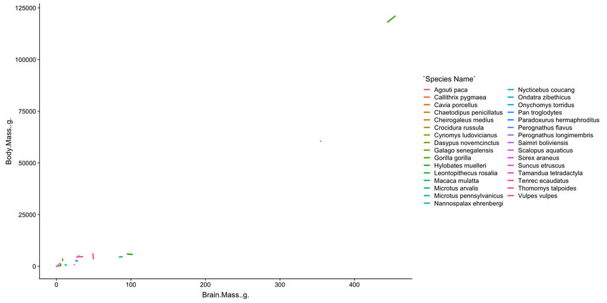

```r
data.BoddyEtAl.2.agg[data.BoddyEtAl.1][
  !(abs(Brain.Mass..g.-`Brain Mass (g)`) <= 1e-6 &
      abs(Body.Mass..g.-`Body Mass (g)`) <= 1e-4), {
        linetypeValues = rep(1, length.out = .N)
        names(linetypeValues) <- `Species Name`
        colourValues = PCMColorPalette(.N, `Species Name`)
        ggplot() +
          geom_segment(aes(x = Brain.Mass..g., xend = `Brain Mass (g)`,
                           y = Body.Mass..g., yend = `Body Mass (g)`,
                           colour = `Species Name`,
                           linetype = `Species Name`), lineend = "round", size = 1.2) +
          scale_linetype_manual(values = linetypeValues) +
          scale_colour_manual(values = colourValues)
      }

  ]
```

```r
data.BoddyEtAl.2 <- data.BoddyEtAl.2[i %in% unique(do.call(c, data.BoddyEtAl.2.agg$i))]
```

## Calculating the brain- and body-mass SDs across groupings of measurements of 1 individual

```r
data.BoddyEtAl.2 <- rbindlist(
  list(
    data.BoddyEtAl.2[
      No..Individuals == 1,
      list(Brain.Mass..g. = mean(Brain.Mass..g.),
           Brain.Mass.SD = sd(Brain.Mass..g.),
           Body.Mass..g. = mean(Body.Mass..g.),
           Body.Mass.SD = sd(Body.Mass..g.),
           Sex =
             if(length(unique(Sex[!is.na(Sex)])) == 0) {
               as.character(NA)
             } else if(length(unique(Sex[!is.na(Sex)])) == 1) {
               as.character(unique(Sex[!is.na(Sex)]))
             } else {
               "M&F"
             },
           No..Individuals = sum(No..Individuals),
           Source = do.call(paste, c(as.list(unique(Source)), sep = ";")),
           Notes = paste(do.call(paste,
                                 c(as.list(unique(Notes)), sep=";")),
                         paste("; Mitov: combining entries with No..Individuals == 1 for",
                               .N, " entries.", sep = " ")),
           Order = unique(Order),
           i = list(i)),
      keyby = SpeciesName2],
    data.BoddyEtAl.2[sapply(No..Individuals, function(noi) is.na(noi) || noi != 1),
      list(SpeciesName2,
           Brain.Mass..g.,
           Brain.Mass.SD,
           Body.Mass..g.,
           Body.Mass.SD,
           Sex = Sex,
           No..Individuals,
           Source,
           Notes,
           Order,
           i)
    ]
  )
)
```

```r
data.BoddyEtAl.2[, sum(!is.na(Brain.Mass.SD) & !is.na(Body.Mass.SD))]
```

```
## [1] 159
```

```r
data.BoddyEtAl.2[, sum(!is.na(Brain.Mass.SD) & is.na(Body.Mass.SD))]
```

```
## [1] 0
```

```r
data.BoddyEtAl.2[, sum(is.na(Brain.Mass.SD) & !is.na(Body.Mass.SD))]
```

```
## [1] 63
```

```r
data.BoddyEtAl.2[, sum(is.na(Brain.Mass.SD) & is.na(Body.Mass.SD))]
```

```
## [1] 535
```

## Calculating the non-combined SEs

```r
data.BoddyEtAl.2[, Brain.Mass.SE:=Brain.Mass.SD / sqrt(No..Individuals)]
data.BoddyEtAl.2[, Body.Mass.SE:=Body.Mass.SD / sqrt(No..Individuals)]
```

## Calculating the brain and body mass means and combined standard errors

(Baker 1963) derived a formula for calculating the combined standard error from the standard errors, the means and the counts of two samples:

$$e^{2}=\frac{1}{n(n-1)}\bigg[n_{1}(n_{1}-1)e_{1}^{2}+n_{2}(n_{2}-1)e_{2}^{2}+\frac{n_{1}n_{2}}{n}(m_{1}-m_{2})^{2}\bigg],$$
where $n=n_{1}+n_{2}$ is the sum of the sample sizes, $m_{1}$ and $m_{2}$ are the means of the two samples, $e_{1}$ and $e_{2}$ are the standard errors in the two samples and $e$ is the standard error of the combined mean $m=(n_{1}m_{1}+n_{2}m_{2})/n$.

(Baker 1963) also derived a simple formula for calculating the new standard error after each additional measurement ($X_{n}$):
$$e^{2} = \frac{n_{1}-1}{n}e_{1}^2+\frac{(m_{1}-X_{n})^2}{n^{2}},$$
where $n=n_{1}+1$.

```r
comb.se.add1 <- function(m1, n1, e1, Xn) {
  n <- n1 + 1
  sqrt((n1-1)/n * e1^2 + (m1 - Xn)^2 / n^2)
}

comb.se <- function(m1, n1, e1, m2, n2, e2) {
  if(is.na(n1) || is.na(n2) || is.na(m1) || is.na(m2) || is.na(e1) || is.na(e2)) {
    as.double(NA)
  } else if(n1 <= 1 && n2 <= 1) {
    as.double(NA)
  } else if(n1 > 1 && n2 == 1) {
    comb.se.add1(m1, n1, e1, m2)
  } else if(n1 == 1 && n2 > 1) {
    comb.se.add1(m2, n2, e2, m1)
  } else {
    n <- n1 + n2
    sqrt(1/(n*(n-1)) * (n1*(n1-1)*e1^2 + (n2*(n2-1)*e2^2 + n1*n2/n* (m1 - m2)^2)))
  }
}

comb.se.vec <- function(m, n, e) {
  k <- length(m)
  if(k == 0) {
    as.double(NA)
  } else if(k == 1) {
    e[1]
  } else {
    o <- order(n, decreasing = TRUE)
    m1 <- m[o][1]
    n1 <- n[o][1]
    e1 <- e[o][1]
    for(i in 2:k) {
      e1 <- comb.se(m1, n1, e1, m[o][i], n[o][i], e[o][i])
      m1 <- (m1*n1 + m[o][i]*n[o][i]) / (n1 + n[o][i])
      n1 <- n1 + n[o][i]
    }
    e1
  }
}
```

```r
data.BoddyEtAl.2 <- data.BoddyEtAl.2[
  , {
    weights <- No..Individuals

    # weights <- rep(1, .N)
    # i.groupOfOnes <- grep("Mitov: combining entries with No..Individuals == 1", Notes)
    # if(length(i.groupOfOnes) > 0) {
    #   weights[i.groupOfOnes] <- No..Individuals[i.groupOfOnes]
    # }
    list(
      Brain.Mass..g. = sum(Brain.Mass..g. * weights) / sum(weights),
      Brain.Mass.SE = comb.se.vec(Brain.Mass..g.,
                                  weights,
                                  Brain.Mass.SE),
      Body.Mass..g. = sum(Body.Mass..g. * weights) / sum(weights),
      Body.Mass.SE = comb.se.vec(Body.Mass..g.,
                                 weights,
                                 Body.Mass.SE),
      Sex =
        if(length(unique(Sex[!is.na(Sex)])) == 0) {
          as.character(NA)
        } else if(length(unique(Sex[!is.na(Sex)])) == 1) {
          as.character(unique(Sex[!is.na(Sex)]))
        } else {
          "M&F"
        },
      No..Individuals = sum(No..Individuals),
      Source = do.call(paste, c(as.list(unique(Source)), sep = "; ")),
      Notes = ifelse(.N > 1,
                     paste(do.call(paste, c(as.list(unique(Notes)), sep=";")),
                           paste0("; Mitov: combined Brain.Mass.SE and Body.Mass.SE for ", .N,
                                  " groups within the same species.")),
                     do.call(paste,
                             c(as.list(unique(Notes)), sep = ";"))),
      Order = unique(Order),
      i = list(unlist(i)))
  }, keyby = SpeciesName2]

data.BoddyEtAl.2
```

```
##                SpeciesName2 Brain.Mass..g. Brain.Mass.SE Body.Mass..g. Body.Mass.SE  Sex No..Individuals                          Source                                                                                                                                                                 …
##   1:         Acomys_wilsoni         0.5800            NA         18.50           NA  M&F              10                       Mace 1981                                                                                                                                                                 …
##   2:     Aepyceros_melampus       175.0000            NA      57610.00           NA    M               2            Crile & Quiring 1940                                                                                                                                                                 …
##   3:    Aeromys_tephromelas        10.3400            NA       1189.00           NA  M&F              10                       Mace 1981                                                                                                                                                                 …
##   4:  Aethomys_chrysophilus         1.2500            NA        117.00           NA  M&F              10                       Mace 1981                                                                                                                                                                 …
##   5:        Aethomys_hindei         1.4200            NA        146.30           NA  M&F              10                       Mace 1981                                                                                                                                                                 …
##  ---
## 626:      Zaglossus_bruijni        37.3468            NA       7500.00           NA <NA>               1                    Macrini 2006                                                 NA ; Mitov: measurements copied from data.BoddyEtAl.1 (https://onlinelibrary.wiley.com/action/downloadSupplement…
## 627: Zalophus_californianus       405.0000            NA      91000.00           NA    F               1             Bininda-Emonds 2000                                                                                                                                                                 …
## 628:        Zapus_hudsonius         0.4936            NA         18.01           NA  M&F              14 Crile & Quiring 1940; Mace 1981 Age class estimated from body mass ; Mitov: combining entries with No..Individuals == 1 for 1  entries.;Age class estimated from body mass;"Brain mass corrected…
## 629:         Zapus_princeps         0.5000            NA         24.50           NA  M&F              10                       Mace 1981                                                                                                                                                                 …
## 630:   Zygogeomys_trichopus         3.9472       0.05383        545.00        18.94    M               3                     Hafner 1984                                                                                                                                                                 …
```

### Linear models of the SEs after combining SEs from different groups within the same species

```r
lm.Brain.SE.a <- data.BoddyEtAl.2[
    Brain.Mass.SE*sqrt(No..Individuals) <= 2000,
    lm(Brain.Mass.SE~0+Brain.Mass..g.+Body.Mass.SE)]
lm.Brain.SE.b <- data.BoddyEtAl.2[
    Brain.Mass.SE*sqrt(No..Individuals) <= 2000,
    lm(Brain.Mass.SE~0+Brain.Mass..g.+Body.Mass..g.)]
lm.Brain.SE.c <- data.BoddyEtAl.2[
    Brain.Mass.SE*sqrt(No..Individuals) <= 2000,
    lm(Brain.Mass.SE~0+Brain.Mass..g.)]
lm.Body.SE.a <- data.BoddyEtAl.2[
    Body.Mass.SE*sqrt(No..Individuals) <= 2000000,
    lm(Body.Mass.SE~0+Body.Mass..g.+Brain.Mass.SE)]
lm.Body.SE.b <- data.BoddyEtAl.2[
    Body.Mass.SE*sqrt(No..Individuals) <= 2000000,
    lm(Body.Mass.SE~0+Body.Mass..g.+Brain.Mass..g.)]
lm.Body.SE.c <- data.BoddyEtAl.2[
    Body.Mass.SE*sqrt(No..Individuals) <= 2000000,
    lm(Body.Mass.SE~0+Body.Mass..g.)]

summary(lm.Brain.SE.a)
```

```
##
## Call:
## lm(formula = Brain.Mass.SE ~ 0 + Brain.Mass..g. + Body.Mass.SE)
##
## Residuals:
##    Min     1Q Median     3Q    Max
## -58.03  -2.89  -0.16   2.10  43.21
##
## Coefficients:
##                Estimate Std. Error t value Pr(>|t|)
## Brain.Mass..g. 4.23e-02   2.15e-03    19.7   <2e-16 ***
## Body.Mass.SE   1.69e-04   9.14e-06    18.5   <2e-16 ***
## ---
## Signif. codes:  0 '***' 0.001 '**' 0.01 '*' 0.05 '.' 0.1 ' ' 1
##
## Residual standard error: 13.4 on 85 degrees of freedom
## Multiple R-squared:  0.938,  Adjusted R-squared:  0.936
## F-statistic:  642 on 2 and 85 DF,  p-value: <2e-16
```

```r
summary(lm.Brain.SE.b)
```

```
##
## Call:
## lm(formula = Brain.Mass.SE ~ 0 + Brain.Mass..g. + Body.Mass..g.)
##
## Residuals:
##     Min      1Q  Median      3Q     Max
## -109.88   -0.40    0.04    2.80  124.28
##
## Coefficients:
##                Estimate Std. Error t value Pr(>|t|)
## Brain.Mass..g. 1.99e-02   6.11e-03    3.25   0.0017 **
## Body.Mass..g.  7.94e-05   1.03e-05    7.73    2e-11 ***
## ---
## Signif. codes:  0 '***' 0.001 '**' 0.01 '*' 0.05 '.' 0.1 ' ' 1
##
## Residual standard error: 23 on 85 degrees of freedom
## Multiple R-squared:  0.817,  Adjusted R-squared:  0.812
## F-statistic:  189 on 2 and 85 DF,  p-value: <2e-16
```

```r
summary(lm.Brain.SE.c)
```

```
##
## Call:
## lm(formula = Brain.Mass.SE ~ 0 + Brain.Mass..g.)
##
## Residuals:
##    Min     1Q Median     3Q    Max
## -64.30  -3.34  -0.42   0.39 235.82
##
## Coefficients:
##                Estimate Std. Error t value Pr(>|t|)
## Brain.Mass..g.  0.05949    0.00432    13.8   <2e-16 ***
## ---
## Signif. codes:  0 '***' 0.001 '**' 0.01 '*' 0.05 '.' 0.1 ' ' 1
##
## Residual standard error: 29.8 on 86 degrees of freedom
## Multiple R-squared:  0.688,  Adjusted R-squared:  0.684
## F-statistic:  190 on 1 and 86 DF,  p-value: <2e-16
```

```r
summary(lm.Body.SE.a)
```

```
##
## Call:
## lm(formula = Body.Mass.SE ~ 0 + Body.Mass..g. + Brain.Mass.SE)
##
## Residuals:
##    Min     1Q Median     3Q    Max
## -80410  -5758   -603     -6 261348
##
## Coefficients:
##               Estimate Std. Error t value Pr(>|t|)
## Body.Mass..g.   0.0756     0.0176    4.29  4.8e-05 ***
## Brain.Mass.SE 535.6841    96.8191    5.53  3.4e-07 ***
## ---
## Signif. codes:  0 '***' 0.001 '**' 0.01 '*' 0.05 '.' 0.1 ' ' 1
##
## Residual standard error: 38700 on 85 degrees of freedom
##   (57 observations deleted due to missingness)
## Multiple R-squared:  0.876,  Adjusted R-squared:  0.873
## F-statistic:  301 on 2 and 85 DF,  p-value: <2e-16
```

```r
summary(lm.Body.SE.b)
```

```
##
## Call:
## lm(formula = Body.Mass.SE ~ 0 + Body.Mass..g. + Brain.Mass..g.)
##
## Residuals:
##     Min      1Q  Median      3Q     Max
## -184790    -764     -85      -3  250803
##
## Coefficients:
##                Estimate Std. Error t value Pr(>|t|)
## Body.Mass..g.    0.1596     0.0158    10.1   <2e-16 ***
## Brain.Mass..g.   4.0429    10.1426     0.4     0.69
## ---
## Signif. codes:  0 '***' 0.001 '**' 0.01 '*' 0.05 '.' 0.1 ' ' 1
##
## Residual standard error: 34900 on 142 degrees of freedom
## Multiple R-squared:  0.832,  Adjusted R-squared:  0.829
## F-statistic:  351 on 2 and 142 DF,  p-value: <2e-16
```

```r
summary(lm.Body.SE.c)
```

```
##
## Call:
## lm(formula = Body.Mass.SE ~ 0 + Body.Mass..g.)
##
## Residuals:
##     Min      1Q  Median      3Q     Max
## -188936    -601     -54      -1  249762
##
## Coefficients:
##               Estimate Std. Error t value Pr(>|t|)
## Body.Mass..g.  0.16537    0.00622    26.6   <2e-16 ***
## ---
## Signif. codes:  0 '***' 0.001 '**' 0.01 '*' 0.05 '.' 0.1 ' ' 1
##
## Residual standard error: 34800 on 143 degrees of freedom
## Multiple R-squared:  0.832,  Adjusted R-squared:  0.83
## F-statistic:  706 on 1 and 143 DF,  p-value: <2e-16
```

### Inferring the SEs using the linear models

In the above linear regressions, we excluded one data point having Brain.Mass.SD > 2000 and one data point having Body.Mass.SD > 2000000, because these data-points were apparently outliers (visual analysis). Including these data-point in the models resulted in lower values for $R_{adj}^2$.

The model lm.Body.SE.c has been chosen for inferring the missing Body.Mass.SE:

We retain the models lm.Brain.SE.a and lm.Body.SE.c.

```r
predict.Brain.Mass.SE <- function(Brain.Mass..g., Body.Mass.SE) {
  coefs <- coef(lm.Brain.SE.a)
  coefs[1]*Brain.Mass..g.+coefs[2]*Body.Mass.SE
}

predict.Body.Mass.SE <- function(Body.Mass..g.) {
  coefs <- coef(lm.Body.SE.c)
  coefs[1]*Body.Mass..g.
}

data.BoddyEtAl.2[
  is.na(Body.Mass.SE),
  Notes:=paste(Notes, "; Mitov: Body.Mass.SE inferred using model lm.Body.SE.c")]
data.BoddyEtAl.2[
  is.na(Body.Mass.SE),
  Body.Mass.SE:=predict.Body.Mass.SE(Body.Mass..g.)]

data.BoddyEtAl.2[
  is.na(Brain.Mass.SE),
  Notes:=paste(Notes, "; Mitov: Brain.Mass.SE inferred using model lm.Brain.SE.a")]
data.BoddyEtAl.2[
  is.na(Brain.Mass.SE),
  Brain.Mass.SE:=predict.Brain.Mass.SE(Brain.Mass..g., Body.Mass.SE)]
```

### A plot of the observed and inferred standard errors against the brain and body mass weighted means:

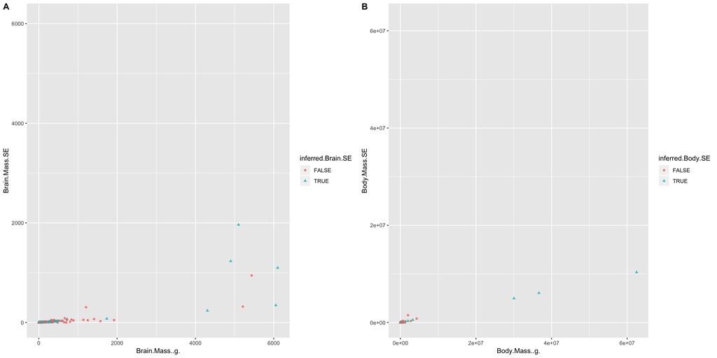

```r
# introduce these two columns for the coloring
data.BoddyEtAl.2[, inferred.Brain.SE:=FALSE]
data.BoddyEtAl.2[grep("Brain.Mass.SE inferred", Notes), inferred.Brain.SE:=TRUE]

data.BoddyEtAl.2[, inferred.Body.SE:=FALSE]
data.BoddyEtAl.2[grep("Body.Mass.SE inferred", Notes), inferred.Body.SE:=TRUE]

pl.Brain.SE <- data.BoddyEtAl.2[
  ,
  ggplot() +
    geom_point(aes(x = Brain.Mass..g.,
                   y = Brain.Mass.SE,
                   colour = inferred.Brain.SE,
                   shape = inferred.Brain.SE), alpha = 0.8) +
    scale_x_continuous(limits = c(0, max(Brain.Mass..g.))) +
    scale_y_continuous(limits = c(0, max(Brain.Mass..g.))) +
    theme_grey()]

pl.Body.SE <- data.BoddyEtAl.2[
  ,
  ggplot() +
    geom_point(aes(x = Body.Mass..g.,
                   y = Body.Mass.SE,
                   colour = inferred.Body.SE,
                   shape = inferred.Body.SE), alpha = 0.8) +
    scale_x_continuous(limits = c(0, max(Body.Mass..g.))) +
    scale_y_continuous(limits = c(0, max(Body.Mass..g.))) +
    theme_grey()]

plot_grid(pl.Brain.SE, pl.Body.SE, labels = LETTERS[1:2])
```

## Calculate the confidence intervals for the brain and body mass measurements

```r
data.BoddyEtAl.2[, Brain.Mass..g.CI95.lower:=Brain.Mass..g. - 1.96*Brain.Mass.SE]
data.BoddyEtAl.2[, Brain.Mass..g.CI95.upper:=Brain.Mass..g. + 1.96*Brain.Mass.SE]

data.BoddyEtAl.2[, Body.Mass..g.CI95.lower:=Body.Mass..g. - 1.96*Body.Mass.SE]
data.BoddyEtAl.2[, Body.Mass..g.CI95.upper:=Body.Mass..g. + 1.96*Body.Mass.SE]
```

## Check overlap in the mean values between data.BoddyEtAl.1 data.BoddyEtAl.2

```r
data.BoddyEtAl.2[data.BoddyEtAl.1][
    abs(Brain.Mass..g.-`Brain Mass (g)`) <= 1e-6 &
    abs(Body.Mass..g.-`Body Mass (g)`) <= 1e-4]
```

```
##                SpeciesName2 Brain.Mass..g. Brain.Mass.SE Body.Mass..g. Body.Mass.SE  Sex No..Individuals               Source                                                                                                                                                                            …
##   1:         Acomys_wilsoni          0.580       0.02505          18.5        3.059  M&F              10            Mace 1981                                                                                                                                     "Body mass averaged from Silva & Downin…
##   2:     Aepyceros_melampus        175.000       9.01463       57610.0     9527.153    M               2 Crile & Quiring 1940                                                                                                                                                                            …
##   3:    Aeromys_tephromelas         10.340       0.47069        1189.0      196.629  M&F              10            Mace 1981                                                                                                                                                                            …
##   4:  Aethomys_chrysophilus          1.250       0.05615         117.0       19.349  M&F              10            Mace 1981                                                                                                                                                                            …
##   5:        Aethomys_hindei          1.420       0.06416         146.3       24.194  M&F              10            Mace 1981                                                                                                                                                                            …
##  ---
## 522:          Xerus_rutilus          5.090       0.22421         317.5       52.506  M&F              10            Mace 1981                                                                                                                                                                            …
## 523:      Zaglossus_bruijni         37.347       1.78971        7500.0     1240.299 <NA>               1         Macrini 2006 NA ; Mitov: measurements copied from data.BoddyEtAl.1 (https://onlinelibrary.wiley.com/action/downloadSupplement?doi=10.1111%2Fj.1420-9101.2012.02491.x&file=JEB_2491_sm_Ta…
## 524: Zalophus_californianus        405.000      19.67859       91000.0    15048.966    F               1  Bininda-Emonds 2000                                                                                                                                                                            …
## 525:         Zapus_princeps          0.500       0.02184          24.5        4.052  M&F              10            Mace 1981                                                                                                                                                                            …
## 526:   Zygogeomys_trichopus          3.947       0.05383         545.0       18.937    M               3          Hafner 1984                                                                                                                                                                            …
```

```r
data.BoddyEtAl.2[data.BoddyEtAl.1][
  !(abs(Brain.Mass..g.-`Brain Mass (g)`) <= 1e-6 &
    abs(Body.Mass..g.-`Body Mass (g)`) <= 1e-4)]
```

```
##               SpeciesName2 Brain.Mass..g. Brain.Mass.SE Body.Mass..g. Body.Mass.SE  Sex No..Individuals                                                            Source                                                                                                                                …
##   1:           Agouti_paca        28.9000       1.35146       4607.00      761.875    F               1                                          Sherwood data/this study                          Estimated age of species: >2 y; Body mass estimated from Nowak 1991 ; Mitov: Inferred No..Individuals …
##   2:     Alouatta_palliata        49.4295       2.25348       5805.68      960.105  M&F              38                                              Crile & Quiring 1940                                                                                                                                …
##   3:       Aotus_lemurinus       112.1765       4.99917       9066.65     1499.381  M&F              17                                              Crile & Quiring 1940                                                                                                                                …
##   4:     Aotus_trivirgatus        17.1768       0.74552        674.45      111.536  M&F             267 Sherwood data/this study;Warncke 1908; Bronson 1981; Stephan 1981                                                                                                                                …
##   5:   Apodemus_sylvaticus         0.5809       0.02510         18.87        3.121  M&F              11                        Count 1947 (Brummelkamp 1939b) ; Mace 1981 Age class estimated from body mass ; Mitov: Inferred No..Individuals - median from the present No..Individuals for the correspo…
##  ---
## 100:       Thomomys_bottae         1.4608       0.06624        159.02       26.298  M&F              17                                            Hafner 1984; Mace 1981                                                                                                                                …
## 101:    Thomomys_talpoides         1.7765       0.07834        113.75       18.812  M&F              13                                            Hafner 1984; Mace 1981                                                                                                                                …
## 102: Trichosurus_vulpecula        11.3962       0.53485       1885.41      311.797 <NA>              17                                        Warncke 1908; Ashwell 2007                                                                                                                                …
## 103:         Vulpes_vulpes        49.1000       4.55448       5972.84     1516.600    F               3                Crile & Quiring 1940;Glendenning 1998;Warncke 1908                                                                                                                                …
## 104:       Zapus_hudsonius         0.4936       0.02138         18.01        2.978  M&F              14                                   Crile & Quiring 1940; Mace 1981                                                                              Age class estimated from body mass ; Mitov: combin…
```

```r
data.BoddyEtAl.2[data.BoddyEtAl.1][
  `Brain Mass (g)` >= Brain.Mass..g.CI95.lower &
    `Brain Mass (g)` <= Brain.Mass..g.CI95.upper &
    `Body Mass (g)` >= Body.Mass..g.CI95.lower &
    `Body Mass (g)` <= Body.Mass..g.CI95.upper][
      , list(SpeciesName2,
             Brain.Mass..g.,
             Brain.Mass..g.CI95.lower,
             Brain.Mass..g.CI95.upper,
             `Brain Mass (g)`,
             Body.Mass..g.,
             Body.Mass..g.CI95.lower,
             Body.Mass..g.CI95.upper,
             `Body Mass (g)`,
             No..Individuals,
             Brain.Mass.SE,
             Body.Mass.SE,
             inferred.Brain.SE,
             inferred.Body.SE,
             Source,
             Notes,
             i.Notes,
             Order)
    ]
```

```
##                SpeciesName2 Brain.Mass..g. Brain.Mass..g.CI95.lower Brain.Mass..g.CI95.upper Brain Mass (g) Body.Mass..g. Body.Mass..g.CI95.lower Body.Mass..g.CI95.upper Body Mass (g) No..Individuals Brain.Mass.SE Body.Mass.SE inferred.Brain.SE inferred.Body.SE               Source               …
##   1:         Acomys_wilsoni          0.580                   0.5309                   0.6291          0.580          18.5                   12.50                   24.50          18.5              10       0.02505        3.059              TRUE             TRUE            Mace 1981               …
##   2:     Aepyceros_melampus        175.000                 157.3313                 192.6687        175.000       57610.0                38936.78                76283.22       57610.0               2       9.01463     9527.153              TRUE             TRUE Crile & Quiring 1940               …
##   3:    Aeromys_tephromelas         10.340                   9.4175                  11.2625         10.340        1189.0                  803.61                 1574.39        1189.0              10       0.47069      196.629              TRUE             TRUE            Mace 1981               …
##   4:  Aethomys_chrysophilus          1.250                   1.1399                   1.3601          1.250         117.0                   79.08                  154.92         117.0              10       0.05615       19.349              TRUE             TRUE            Mace 1981               …
##   5:        Aethomys_hindei          1.420                   1.2942                   1.5458          1.420         146.3                   98.88                  193.72         146.3              10       0.06416       24.194              TRUE             TRUE            Mace 1981               …
##  ---
## 596:          Xerus_rutilus          5.090                   4.6505                   5.5295          5.090         317.5                  214.59                  420.41         317.5              10       0.22421       52.506              TRUE             TRUE            Mace 1981               …
## 597:      Zaglossus_bruijni         37.347                  33.8389                  40.8546         37.347        7500.0                 5069.01                 9930.99        7500.0               1       1.78971     1240.299              TRUE             TRUE         Macrini 2006 NA ; Mitov: me…
## 598: Zalophus_californianus        405.000                 366.4300                 443.5700        405.000       91000.0                61504.03               120495.97       91000.0               1      19.67859    15048.966              TRUE             TRUE  Bininda-Emonds 2000               …
## 599:         Zapus_princeps          0.500                   0.4572                   0.5428          0.500          24.5                   16.56                   32.44          24.5              10       0.02184        4.052              TRUE             TRUE            Mace 1981               …
## 600:   Zygogeomys_trichopus          3.947                   3.8416                   4.0527          3.947         545.0                  507.88                  582.12         545.0               3       0.05383       18.937             FALSE            FALSE          Hafner 1984               …
```

```r
data.BoddyEtAl.2[data.BoddyEtAl.1][
  !(`Brain Mass (g)` >= Brain.Mass..g.CI95.lower &
      `Brain Mass (g)` <= Brain.Mass..g.CI95.upper &
      `Body Mass (g)` >= Body.Mass..g.CI95.lower &
      `Body Mass (g)` <= Body.Mass..g.CI95.upper)][
        , list(SpeciesName2,
             Brain.Mass..g.,
             Brain.Mass..g.CI95.lower,
             Brain.Mass..g.CI95.upper,
             `Brain Mass (g)`,
             Body.Mass..g.,
             Body.Mass..g.CI95.lower,
             Body.Mass..g.CI95.upper,
             `Body Mass (g)`,
             No..Individuals,
             Brain.Mass.SE,
             Body.Mass.SE,
             inferred.Brain.SE,
             inferred.Body.SE,
             Source,
             Notes,
             i.Notes,
             Order)
      ]
```

```
##                 SpeciesName2 Brain.Mass..g. Brain.Mass..g.CI95.lower Brain.Mass..g.CI95.upper Brain Mass (g) Body.Mass..g. Body.Mass..g.CI95.lower Body.Mass..g.CI95.upper Body Mass (g) No..Individuals Brain.Mass.SE Body.Mass.SE inferred.Brain.SE inferred.Body.SE                                   …
##  1:              Agouti_paca       28.90000                 26.25114                 31.54886        35.2167      4607.000                3113.726                6100.274       4607.00               1      1.351458     761.8746              TRUE             TRUE                                   …
##  2:          Ateles_paniscus      103.71154                 99.26130                108.16178       108.9600      4841.154                3939.216                5743.092       3430.00              26      2.270529     460.1726             FALSE            FALSE                                   …
##  3:      Atherurus_africanus       19.09091                 17.35610                 20.82572        21.8850      2770.000                1872.156                3667.844       3152.50              11      0.885109     458.0839              TRUE             TRUE                                   …
##  4:       Blarina_brevicauda        0.32482                  0.29693                  0.35271         0.2888        17.447                  11.792                  23.103         17.70              78      0.014229       2.8853              TRUE             TRUE                                   …
##  5:             Cavia_aperea        5.04545                  4.60050                  5.49041         4.0350       485.182                 327.919                 642.445        306.45              11      0.227016      80.2361              TRUE             TRUE                                   …
##  6:          Cavia_porcellus        4.23846                  3.86285                  4.61407         4.8333       440.846                 297.954                 583.738        476.00              13      0.191637      72.9042              TRUE             TRUE                  Glendenning 1998;…
##  7: Chrysochloris_stuhlmanni        1.26500                  1.15699                  1.37301         1.0550        56.883                  38.446                  75.321         50.05              12      0.055106       9.4070              TRUE             TRUE                                   …
##  8:     Dasypus_novemcinctus        7.67000                  6.84629                  8.49371         8.5000      3424.667                2314.624                4534.709       2743.50              12      0.420263     566.3482              TRUE             TRUE          Crile & Quiring 1940;Glen…
##  9:          Jaculus_jaculus        1.26818                  1.15990                  1.37646         1.5300        57.000                  38.525                  75.475         64.20              11      0.055244       9.4263              TRUE             TRUE                           Count 19…
## 10:       Lagostomus_maximus       15.81818                 14.25377                 17.38259        12.6600      4611.727                3116.921                6106.534       4270.75              11      0.798170     762.6563              TRUE             TRUE                           Count 19…
## 11:            Lepus_timidus       13.78182                 12.48461                 15.07902        15.0950      2817.545                1904.290                3730.801       3274.50              11      0.661840     465.9466              TRUE             TRUE                           Count 19…
## 12:      Macaca_fascicularis       63.89808                 61.46482                 66.33133        66.9273      3466.231                3101.484                3830.978       3109.45              52      1.241456     186.0955             FALSE            FALSE                             Hrdlic…
## 13:        Microtus_agrestis        0.60000                  0.54893                  0.65107         0.7350        24.136                  16.313                  31.960         32.40              11      0.026058       3.9915              TRUE             TRUE                           Count 19…
## 14:          Mustela_erminea        4.99800                  4.57472                  5.42128         4.5700       161.580                 109.207                 213.953        156.43               5      0.215958      26.7210              TRUE             TRUE              Crile & Quiring 1940;…
```

[output cut: 17 more lines]

## Use the linear models to correct SEs for entries in data.BoddyEtAl.2, without match with Brain- and Body-mass values in data.BoddyEtAl.1

```r
data.BoddyEtAl.2 <- data.BoddyEtAl.2[data.BoddyEtAl.1]

data.BoddyEtAl.2[, `Brain Mass SE (g)`:=Brain.Mass.SE]
data.BoddyEtAl.2[, `Body Mass SE (g)`:=Body.Mass.SE]

data.BoddyEtAl.2[
  !(abs(Brain.Mass..g. - `Brain Mass (g)`) <= 1e-6 &
      abs(Body.Mass..g. - `Body Mass (g)`) <= 1e-4),
  Notes:=paste(Notes, "; Mitov: corrected SEs for entries in data.BoddyEtAl.2, without match with Brain- and Body-mass values in data.BoddyEtAl.1 (using lm.Body.SE.c and lm.Brain.SE.a).")]

data.BoddyEtAl.2[
  !(abs(Brain.Mass..g. - `Brain Mass (g)`) <= 1e-6 &
      abs(Body.Mass..g. - `Body Mass (g)`) <= 1e-4),
  `Body Mass SE (g)`:=predict.Body.Mass.SE(`Body Mass (g)`)]

data.BoddyEtAl.2[
  !(abs(Brain.Mass..g. - `Brain Mass (g)`) <= 1e-6 &
      abs(Body.Mass..g. - `Body Mass (g)`) <= 1e-4),
  `Brain Mass SE (g)`:=predict.Brain.Mass.SE(`Brain Mass (g)`, `Body Mass SE (g)`)]
```

```r
data.BoddyEtAl.2[, `Brain Mass CI 95% lower (g)`:=`Brain Mass (g)` - 1.96*`Brain Mass SE (g)`]
data.BoddyEtAl.2[, `Brain Mass CI 95% upper (g)`:=`Brain Mass (g)` + 1.96*`Brain Mass SE (g)`]

data.BoddyEtAl.2[, `Body Mass CI 95% lower (g)`:=`Body Mass (g)` - 1.96*`Body Mass SE (g)`]
data.BoddyEtAl.2[, `Body Mass CI 95% upper (g)`:=`Body Mass (g)` + 1.96*`Body Mass SE (g)`]
```

```r
data.BoddyEtAl.2 <- data.BoddyEtAl.2[
  , list(SpeciesName2,
         `Species Name`,
         `Brain Mass (g)`,
         `Brain Mass SE (g)`,
         `Brain Mass CI 95% lower (g)`,
         `Brain Mass CI 95% upper (g)`,
         `Body Mass (g)`,
         `Body Mass SE (g)`,
         `Body Mass CI 95% lower (g)`,
         `Body Mass CI 95% upper (g)`,
         Order,
         Source,
         Notes = paste0(Notes, "; ", i.Notes)
         )]
```

### A plot of the final SEs againt Brain-mass and Body-mass

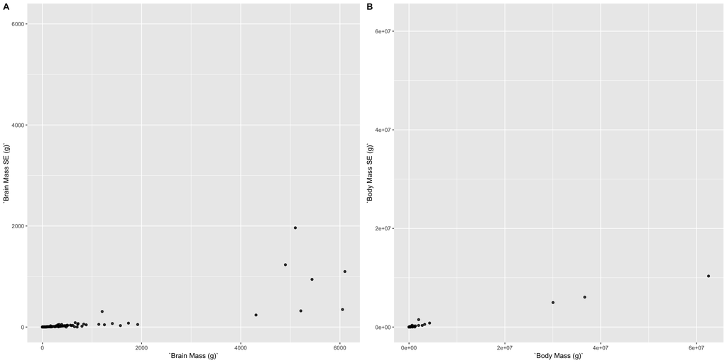

```r
pl.Brain.SE <- data.BoddyEtAl.2[
  ,
  ggplot() +
    geom_point(aes(x = `Brain Mass (g)`,
                   y = `Brain Mass SE (g)`
                   ), alpha = 0.8) +
    scale_x_continuous(limits = c(0, max(`Brain Mass (g)`))) +
    scale_y_continuous(limits = c(0, max(`Brain Mass (g)`))) +
    theme_grey()]

pl.Body.SE <- data.BoddyEtAl.2[
  ,
  ggplot() +
    geom_point(aes(x = `Body Mass (g)`,
                   y = `Body Mass SE (g)`
                   ), alpha = 0.8) +
    scale_x_continuous(limits = c(0, max(`Body Mass (g)`))) +
    scale_y_continuous(limits = c(0, max(`Body Mass (g)`))) +
    theme_grey()]

plot_grid(pl.Brain.SE, pl.Body.SE, labels = LETTERS[1:2])
```

## Log10 transformation of values and standard errors

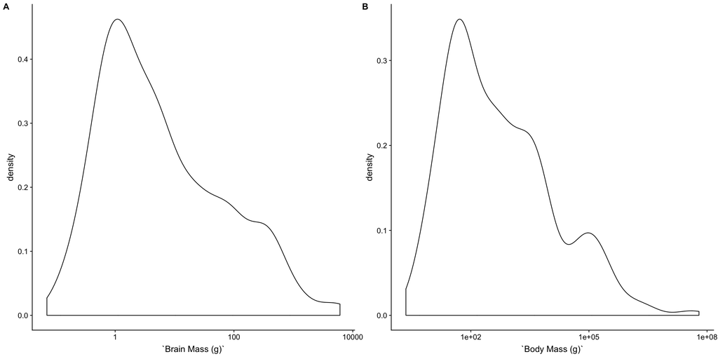

```r
pl1 <- ggplot(data.BoddyEtAl.2) +
  geom_density(aes(x=`Brain Mass (g)`)) +
  scale_x_continuous(trans = "log10")
pl2 <- ggplot(data.BoddyEtAl.2) +
  geom_density(aes(x = `Body Mass (g)`)) +
  scale_x_continuous(trans = "log10")
plot_grid(pl1, pl2, labels = LETTERS[1:2])
```

We assume that for a given species, each of the two traits has a sample mean that is log-normally distributed with mean equal to the true mean value for the species and standard deviation, equal to the true standard error for the species. Let’s denote by $Y$ any one of the two traits. Assuming that $Y$ is log-normally distributed means that the variable $Z=\ln(Y)$ is normally distributed with mean and variance equal to $\mu_{Z}$ and $\sigma_{Z}^{2}$ for some values of these two parameters. At first glance, this assumption may seem at odds with the central limit theorem, which guarantees that for a large enough $n$ (e.g. $n\geq 30$), the distribution of the sample mean, $\bar{Y}$, is *approximately* normal with mean equal to the population mean, $\mu_{Y}$, and variance equal to the squared standard error, $\sigma_{e,Y}^2$. This, however, does not imply that the sample mean is normally distributed, because a normal distribution has non-zero density over all real numbers, whereas traits like body-mass and brain-mass can only assume non-negative values. Assuming a log-normal distribution solves this issue because its domain is limited to the positive real numbers. Moreover, if the coefficent of variation $CV_{Y}=\frac{\sigma_{e,Y}}{\mu_{Y}}$ is small, the log-normal distribution obtains a bell-shaped density very similar to a normal distribution.

Let $X=\lg(Y)=\lg(e)\ln(y)$. Following Eqs. 1-5 in (Quan and Zhang 2003), it is possible to estimate $\mu_{X}$ and $\sigma_{X}^{2}$ from estimates of $\mu_{Y}$, $\sigma_{e,Y}^2$:

$$\hat{\sigma_{X}}^2=\big[\lg(e)\big]^2\bigg[\ln(1+\frac{\hat{\sigma_{Y}}^2}{\hat{\mu_{Y}}^2})\bigg]\\
\hat{\mu_{X}}=\lg(e)\bigg[\ln(\hat{\mu_{Y}})-\frac{1}{2}\hat{\sigma_{Z}}^2\bigg]$$

```r
SDLog.lnorm <- function(hatMean, hatMeanSE, base=exp(1)) {
  f <- log(exp(1), base = base)
  sqrt(f^2* log(1 + hatMeanSE^2 / hatMean^2))
}

MeanLog.lnorm <- function(hatMean, hatMeanSE, base=exp(1)) {
  f <- log(exp(1), base = base)
  varLog <- SDLog.lnorm(hatMean, hatMeanSE)^2
  f*(log(hatMean)-0.5*varLog)
}
```

```r
data.BoddyEtAl.2[
  , `lg Brain Mass SE`:=SDLog.lnorm(`Brain Mass (g)`, `Brain Mass SE (g)`, base = 10)]

data.BoddyEtAl.2[
  , `lg Body Mass SE`:=SDLog.lnorm(`Body Mass (g)`, `Body Mass SE (g)`, base = 10)]
```

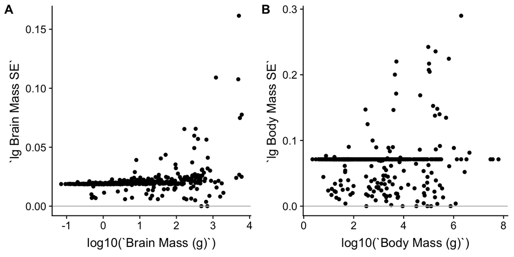

```r
pl1 <- ggplot(data.BoddyEtAl.2) +
  geom_point(aes(x=log10(`Brain Mass (g)`), y=`lg Brain Mass SE`)) +
  geom_abline(intercept = 0, slope = 0, color="grey")

pl2 <- ggplot(data.BoddyEtAl.2) +
  geom_point(aes(x = log10(`Body Mass (g)`), y = `lg Body Mass SE`)) +
  geom_abline(intercept = 0, slope = 0, color="grey")
plot_grid(pl1, pl2, labels = LETTERS[1:2])
```

```r
# random generators of exp of random variables
rlnorm <- function(n, meanlog=0, sdlog = 1, base = exp(1)) {
  base^rnorm(n, meanlog, sdlog)
}

rlunif <- function(n, meanlog=0, sdlog = 1, base = exp(1)) {
  varlog <- sdlog^2
  widthlog <- sdlog*sqrt(12)
  alog <- meanlog - widthlog/2
  blog <- meanlog + widthlog/2
  base^runif(n, alog, blog)
}
```

```r
N.Species <- 10
N.Samples <- 1000
N.Obs <- 100

globalSD <- 0.1
globalMean <- 1

baseLog = exp(1)

seed <- data.table(
  i.spec = 1:N.Species,
  meanLog = rlnorm(N.Species, globalMean, globalSD),
  sdLog = sample(seq(0.01, 0.06, by=0.01), size = N.Species, replace = TRUE))
seed[, seLog:=sdLog/sqrt(N.Obs)]

seed[, MeanY := exp(log(baseLog)*meanLog + log(baseLog)^2*sdLog^2/2)]
seed[, VarY := exp(2*log(baseLog)*meanLog + 4*log(baseLog)^2*sdLog^2/2)-MeanY^2]

data <- rbindlist(lapply(1:N.Samples, function(ii) {
  samp <- copy(seed)[, i.samp:=ii]
  rbindlist(lapply(1:N.Obs, function(jj) {
    copy(samp[, i.obs:=jj])
  }))
}))

setkey(data, i.spec, i.samp, i.obs)

data[, Y:=sapply(1:.N, function(j) rlnorm(1, meanLog[j], sdLog[j], base = baseLog))]
#data[, Y:=sapply(1:.N, function(j) rlunif(1, meanLog[j], sdLog[j], base = baseLog))]
```

```r
ana.1 <- data[, list(
  meanLog = unique(meanLog),
  sdLog = unique(sdLog),
  seLog = unique(seLog),
  MeanY = unique(MeanY),
  VarY = unique(VarY),

  # This should be approximately equal to seLog.
  # This is the true standard error of the LogMean.
  SDLogMeanY = SDLog.lnorm(unique(MeanY), sqrt(unique(VarY)/.N), base = baseLog),

  # This should be approximately equal to meanLog. How close depends on
  # how appropriate the assumption of log-normality for
  # the distribution of the sample mean is.
  MeanLogMeanY = MeanLog.lnorm(unique(MeanY), sqrt(unique(VarY)/.N), base = baseLog),

  hatMeanY = mean(Y),
  hatVarY = var(Y),

  hatSDHatMeanY = sqrt(var(Y)/.N),

  logHatMeanY = log(mean(Y), base = baseLog),

  hatSDLogHatMeanY = SDLog.lnorm(mean(Y), sqrt(var(Y)/.N), base = baseLog),
  hatMeanLogHatMeanY = MeanLog.lnorm(mean(Y), sqrt(var(Y)/.N), base = baseLog),
  meanLogMeanY = MeanLog.lnorm(unique(MeanY), sqrt(unique(VarY)/.N), base = baseLog)),

  by = list(i.spec, i.samp)]
```

```r
ana.2 <- ana.1[, list(
  meanLog = unique(meanLog),
  sdLog = unique(sdLog),
  seLog = unique(seLog),
  MeanY = unique(MeanY),
  VarY = unique(VarY),

  # This should be approximately equal to seLog.
  # This is the true standard error.
  SDLogMeanY = unique(SDLogMeanY),

  # This should be approximately equal to meanLog. How close depends on
  # how appropriate the assumption of log-normality for
  # the distribution of the sample mean is.
  MeanLogMeanY = unique(MeanLogMeanY),

  hatMeanHatMeanY = mean(hatMeanY),
  hatMeanHatVarY = mean(hatVarY),

  hatMeanHatSDHatMeanY = mean(hatSDHatMeanY),

  hatMeanLogHatMeanY = mean(logHatMeanY),

  hatMeanHatSDLogHatMeanY = mean(hatSDLogHatMeanY),
  hatMeanHatMeanLogHatMeanY = mean(hatMeanLogHatMeanY),
  hatMeanMeanLogMeanY = mean(meanLogMeanY)),

  by = i.spec]

ana.2[, list(
  hatMeanLogHatMeanY - meanLog,
  hatMeanHatMeanLogHatMeanY - meanLog,
  hatMeanMeanLogMeanY - meanLog
  )]
```

```
##            V1        V2        V3
##  1: 7.841e-04 7.761e-04 0.0007920
##  2: 7.944e-04 7.864e-04 0.0007920
##  3: 1.528e-04 1.508e-04 0.0001980
##  4: 1.369e-03 1.356e-03 0.0012375
##  5: 2.091e-04 2.071e-04 0.0001980
##  6: 1.117e-03 1.104e-03 0.0012375
##  7: 2.941e-04 2.896e-04 0.0004455
##  8: 6.805e-05 6.755e-05 0.0000495
##  9: 9.373e-04 9.293e-04 0.0007920
## 10: 1.031e-03 1.023e-03 0.0007920
```

# Phylogenetic tree from (Bininda-Emonds et al. 2007)

```r
# download the mammal trees from Bininda-Emmonds 2007. The user running that
# code should have access to the following web-address:
trees <- read.nexus(
  "https://media.nature.com/original/nature-assets/nature/journal/v446/n7135/extref/nature05634-s2.txt"
)
# the mmammalST_bestDates tree containing 4510 tips and 2108 internal nodes
tree.big <- trees[[1]]

# Missing tip in original dataset provided by Prof. Stelling
missingTip <- "Microtus_pennsylvanicus"

# prune all tips that are not found in data.BoddyEtAl.2
tree <- drop.tip(tree.big,
                 tip = union(missingTip,
                             setdiff(tree.big$tip.label,
                                     data.BoddyEtAl.2[, SpeciesName2])))



# test that no terminal branches are of length zero : returns FALSE
# any(tree$edge[tree$edge.length==0, 2]<=629)
# delete branches of length 0
tree <- ladderize(di2multi(tree))
# segment long branches
while(TRUE) {
  points <- PCMTreeLocateMidpointsOnBranches(tree, 16)
  if(length(points$nodes) == 0) {
    break
  } else {
    tree <- PCMTreeInsertSingletons(tree, points$nodes, points$positions)
  }
}

usethis::use_data(tree, overwrite = TRUE)
```

# Create final data matrices

```r
library(MGPMMammals)
data.BoddyEtAl.2 <- data.BoddyEtAl.2[SpeciesName2 %in% tree$tip.label]

data.BoddyEtAl.2[list(tree$tip.label), node:=1:.N]
usethis::use_data(data.BoddyEtAl.2, overwrite = TRUE)
```

```
## ✔ Saving 'data.BoddyEtAl.2' to 'data/data.BoddyEtAl.2.rda'
```

```r
values <- data.BoddyEtAl.2[list(tree$tip.label),
                           rbind(lg_BodyMass=log10(`Body Mass (g)`),
                                 lg_BrainMass=log10(`Brain Mass (g)`))]
colnames(values) <- tree$tip.label
usethis::use_data(values, overwrite = TRUE)
```

```
## ✔ Saving 'values' to 'data/values.rda'
```

```r
SEs <- data.BoddyEtAl.2[list(tree$tip.label),
                        rbind(lg_BodyMass_SE = `lg Body Mass SE`,
                              lg_BrainMass_SE = `lg Brain Mass SE`)]
colnames(SEs) <- tree$tip.label
usethis::use_data(SEs, overwrite = TRUE)
```

```
## ✔ Saving 'SEs' to 'data/SEs.rda'
```

```r
load("Result_FineTuning_BestFit_MammalData_t6.RData")

attr(finalModel, "SE") <- matrix(0.0, 2, 629)
logLik(finalModel)

names(attributes(finalModel))

tips <- dtMammals[list(as.integer(attr(finalModel, "tree")$tip.label)), SpeciesName2]

X2 <- values[, tips]
attr(finalModel, "X") <- X2

logLik(finalModel)

treeFinalModel <- attr(finalModel, "tree")

tree2 <- PCMTreeSetRegimes(
  tree,
  PCMTreeGetStartingNodesRegimes(treeFinalModel),
  inplace = FALSE)

PCMTreeGetStartingNodesRegimes(treeFinalModel)
PCMTreeGetStartingNodesRegimes(tree2)

attr(finalModel, "X") <- values[, tree2$tip.label]
attr(finalModel, "tree") <- tree2 # treeFinalModel
attr(finalModel, "SE") <- SEs[, tree2$tip.label]*0

metaI <- PCMInfo(attr(finalModel, "X"), attr(finalModel, "tree"), finalModel, SEs[, tree2$tip.label])

PCMLik(attr(finalModel, "X"), attr(finalModel, "tree"), finalModel, SEs[, tree2$tip.label])

logLik(finalModel)

#PCMLik(valuesMammals, tree2, finalModel)
#PCMLik(values[, tree2$tip.label], tree2, finalModel)
```

# References

Baker, R W R. 1963. “Expressions for Combining Standard Errors of Two Groups and for Sequential Standard Error.” *Nature* 198 (4): 1020.

Bininda-Emonds, Olaf R P, Marcel Cardillo, Kate E Jones, Ross D E MacPhee, Robin M D Beck, Richard Grenyer, Samantha A Price, Rutger A Vos, John L Gittleman, and Andy Purvis. 2007. “The delayed rise of present-day mammals.” *Nature* 446 (7135): 507–12.

Boddy, A M, M R McGowen, C C Sherwood, L I Grossman, M Goodman, and D E Wildman. 2012. “Comparative analysis of encephalization in mammals reveals relaxed constraints on anthropoid primate and cetacean brain scaling.” *Journal of Evolutionary Biology* 25 (5): 981–94.

Quan, Hui, and Ji Zhang. 2003. “Estimate of standard deviation for a log-transformed variable using arithmetic means and standard deviations.” *Statistics in Medicine* 22 (17): 2723–36.